# **Deep Learning Project, ST2NL2**

### **Authors : Marion FRESQUET, Manel EL KOUCH**

#### **ING2 BIOINF**

```python
import numpy as np
X_images = np.load('X_images.npy')
Y_labels = np.load('Y_labels.npy')
```

## **1. Data Visualization**

Plot 9 random images with labels (face, not-face). Display their respective labels (face, not-face).

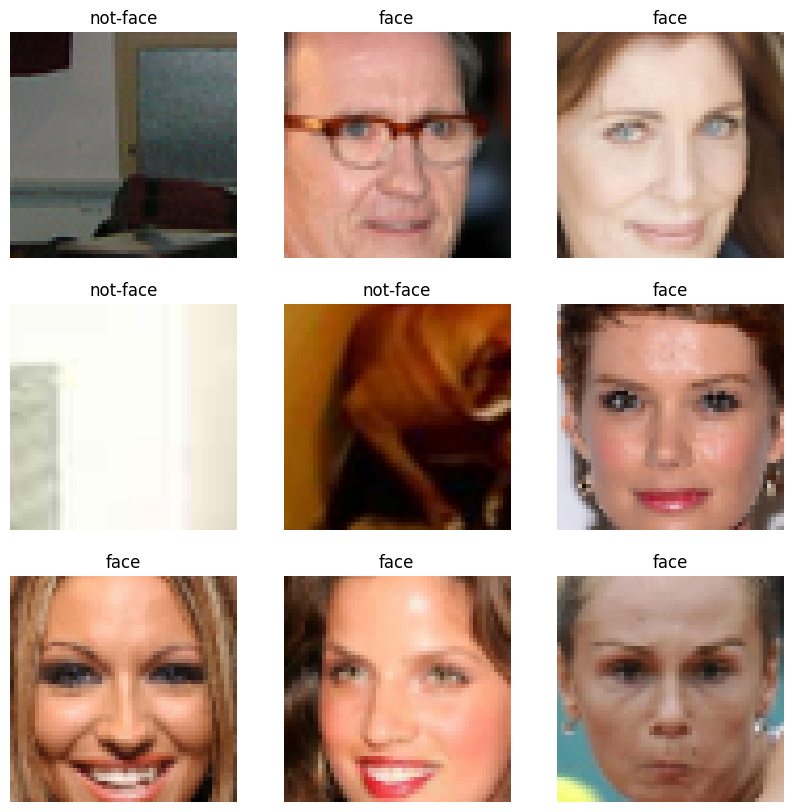

```python
import matplotlib.pyplot as plt

# Generate 9 random indexes
indexes = np.random.choice(len(X_images), 9, replace=False)

# Display
plt.figure(figsize=(10, 10))
for i, idx in enumerate(indexes):
    plt.subplot(3, 3, i + 1)
    plt.imshow(X_images[idx])
    label = "face" if Y_labels[idx] == 1 else "not-face"
    plt.title(label)
    plt.axis('off')
plt.show()
```

The images have low resolution, but the face photos are diverse enough for our model to adapt even when the face is not directly facing the camera.

## **2. Baseline Model**

- Create a deep learning model without the CNN component with 2 hidden dense layers. Use an appropriate data splitting criteria.
- Fine-tune the two hyperparameters: dropout and kernel initializers of the deep neural network using scikit-learn. Test only two choices for each hyperparameter.
- Compute the validation and test scores. What do you observe?
- Save the validation and test scores for future comparison.

**1- Data preparation**

```python
# Checking if our data is already normalized
print(X_images.max(), X_images.min())
```

```
1.0 0.0
```

The images were therefore already standardized, no need to add them to the code.

```python
from sklearn.model_selection import train_test_split
from tensorflow.keras.utils import to_categorical

# Temporary X variable
X = np.load('X_images.npy')

# Flatten
X = X.reshape((X.shape[0], -1))

# Split en train, validation, test
X_train, X_temp, y_train, y_temp = train_test_split(X, Y_labels, test_size=0.3, random_state=42, stratify=Y_labels)
X_val, X_test, y_val, y_test = train_test_split(X_temp, y_temp, test_size=0.5, random_state=42, stratify=y_temp)
```

In this first block, we load the image dataset and prepare it for training. Since we're building a simple fully connected network (not a CNN), we need to flatten the image data. This means converting each 3D image of shape (54, 54, 3) into a 1D vector (length 8748), so that it can be used as input to a dense neural network.

After flattening, we split the data into training, validation, and test sets. We use 70% of the data for training, and the remaining 30% is divided equally between validation and test. Stratification ensures that the distribution of labels (face vs. not-face) remains balanced across all subsets.

**2- Define the Baseline MLP Model Function**

```python
from tensorflow.keras.models import Sequential
from tensorflow.keras.layers import Dense, Dropout
from tensorflow.keras.initializers import HeNormal, GlorotUniform

def build_baseline_model(dropout_rate=0.3, kernel_initializer='glorot_uniform'):
    model = Sequential()
    model.add(Dense(256, activation='relu', kernel_initializer=kernel_initializer, input_shape=(X.shape[1],)))
    model.add(Dropout(dropout_rate))
    model.add(Dense(128, activation='relu', kernel_initializer=kernel_initializer))
    model.add(Dropout(dropout_rate))
    model.add(Dense(1, activation='sigmoid'))  # binaire

    model.compile(optimizer='adam', loss='binary_crossentropy', metrics=['accuracy'])
    return model
```

Here, we define a baseline model composed of fully connected (dense) layers also known as a multilayer perceptron (MLP). This model does not use any convolutional layers, which means it does not capture spatial relationships in the image. It processes the input as a flat array of pixel values.

The model includes two hidden layers: the first with 256 neurons and the second with 128. Both use the ReLU activation function and a configurable weight initializer (glorot_uniform or he_normal). Between these layers, dropout is applied as a regularization technique to prevent overfitting. Finally, the output layer uses a sigmoid activation function to perform binary classification (face or not face). The model is compiled with the Adam optimizer and binary crossentropy loss, which is appropriate for binary classification tasks.

**3- Hyperparameter Testing (Dropout & Initializer)**

```python
from tensorflow.keras.callbacks import EarlyStopping

dropout_values = [0.3, 0.5]
kernel_initializers = ['glorot_uniform', 'he_normal']

results = {}

for dropout in dropout_values:
    for init in kernel_initializers:
        print(f"Training model with dropout={dropout}, initializer={init}")
        model = build_baseline_model(dropout_rate=dropout, kernel_initializer=init)
        early_stop = EarlyStopping(patience=5, restore_best_weights=True)
        history = model.fit(X_train, y_train, epochs=20, batch_size=64,
                            validation_data=(X_val, y_val),
                            callbacks=[early_stop], verbose=0)

        val_loss, val_acc = model.evaluate(X_val, y_val, verbose=0)
        test_loss, test_acc = model.evaluate(X_test, y_test, verbose=0)
        key = f"dropout={dropout}_init={init}"
        results[key] = {'val_acc': val_acc, 'test_acc': test_acc}

        print(f"Validation Accuracy: {val_acc:.4f}, Test Accuracy: {test_acc:.4f}")
```

```
Training model with dropout=0.3, initializer=glorot_uniform
```

```
Validation Accuracy: 0.9822, Test Accuracy: 0.9836
Training model with dropout=0.3, initializer=he_normal
Validation Accuracy: 0.9853, Test Accuracy: 0.9876
Training model with dropout=0.5, initializer=glorot_uniform
Validation Accuracy: 0.9844, Test Accuracy: 0.9878
Training model with dropout=0.5, initializer=he_normal
Validation Accuracy: 0.9758, Test Accuracy: 0.9773
```

In this section, we run a simple hyperparameter tuning loop to test different values of dropout (0.3 and 0.5) and two types of weight initializers (glorot_uniform and he_normal). For each combination, we build a new model using the function defined earlier.

We also apply early stopping to avoid overfitting and unnecessary training. Early stopping monitors the validation performance and stops training if no improvement is observed over 5 consecutive epochs. After training, we evaluate each model on both the validation and test sets and store the results in a dictionary for later comparison. This approach gives us insight into which hyperparameter combination yields the best generalization.

**4- Display and Save Results**

```python
import pandas as pd

df_results = pd.DataFrame(results).T
print(df_results)
```

```
                                  val_acc  test_acc
dropout=0.3_init=glorot_uniform  0.982222  0.983556
dropout=0.3_init=he_normal       0.985333  0.987556
dropout=0.5_init=glorot_uniform  0.984444  0.987778
dropout=0.5_init=he_normal       0.975778  0.977333
```

The dropout hyperparameter seems to have more impact on accuracy than the initializer.

```python
base_scores = {
    "base_val_acc" : df_results["val_acc"].max(),
    "base_test_acc" : df_results["test_acc"].max()
}
print(base_scores)

import json
with open("base_scores.json", "w") as f:
    json.dump(base_scores, f)
```

[output not shown]

## **4. Prediction Plotting Function**

- Write a function to visualize the predicted labels with an indication of the prediction’s probability.
- Correct predictions should be displayed in green, while incorrect ones should be in red.
- Use this function to plot 12 randomly chosen predictions using the baseline model.

**1- Function**

```python
def plot_single_prediction(model, X_images, Y_labels, index, class_names=["not-face", "face"]):
    img = X_images[index]
    true_label = Y_labels[index]

    img_input = img.reshape(1, -1)

    # Make prediction
    prob = model.predict(img_input, verbose=0)[0][0]
    pred_label = 1 if prob >= 0.5 else 0

    color = 'green' if pred_label == true_label else 'red'
    title = f"{class_names[pred_label]} ({prob:.2f})"

    # Plot
    plt.figure(figsize=(3, 3))
    plt.imshow(img.reshape(54, 54, 3))
    plt.title(title, color=color)
    plt.axis('off')
    plt.show()
```

In this function, we select a single image by its index from the dataset and run it through the trained model. The image is reshaped into a flat vector, as expected by the baseline model (which does not process images in 2D like a CNN).

The model outputs a probability between 0 and 1. We convert this to a predicted class (0 or 1) based on a threshold of 0.5. If the probability is close to zero, the model identified "not face" and if the probability is close to 1, the model identified a face. We then compare the prediction with the true label to determine whether it was correct or not. If it’s correct, the predicted label is shown in green; otherwise, it is shown in red.

The function plots the original image (reshaped back to (54, 54, 3)) along with a title indicating the predicted class name and the associated probability. This gives an immediate visual sense of how confident the model is and whether it was right.

**2- Plotting**

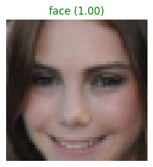

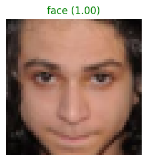

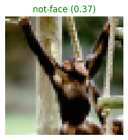

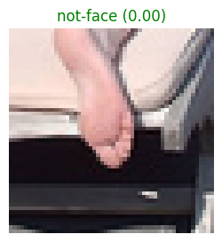

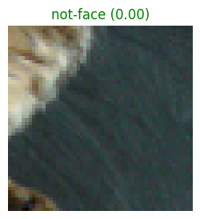

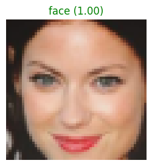

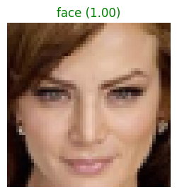

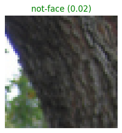

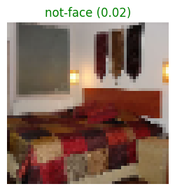

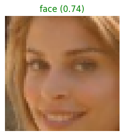

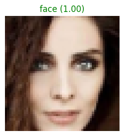

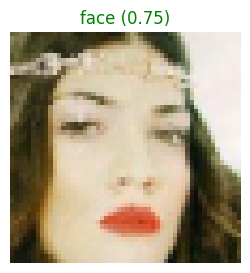

```python
indices = np.random.choice(len(X_images), 12, replace=False)
for idx in indices:
    plot_single_prediction(model, X_images, Y_labels, idx)
```

## **5. CNN Model with Early Stopping**

- Train a more advanced CNN model with 2 hidden CNN layers.
- Implement early stopping to prevent overfitting.
- Compute the validation and test scores.
- Save the validation and test scores for future comparison.
- Use question 4 to plot 4 randomly chosen predictions using CNN model.

**1- Building the CNN**

```python
# Import necessary modules to build the CNN model
from tensorflow.keras.models import Sequential
from tensorflow.keras.layers import Conv2D, MaxPooling2D, Flatten, Dense, Dropout
from tensorflow.keras.callbacks import EarlyStopping

# Reshape the image : number of image, size (54x54), number of channels (3)
X_train_cnn = X_train.reshape(-1, 54, 54, 3)
X_val_cnn = X_val.reshape(-1, 54, 54, 3)
X_test_cnn = X_test.reshape(-1, 54, 54, 3)

# Build CNN Model
model_cnn = Sequential([
    Conv2D(32, (3, 3), activation='relu', input_shape=(54, 54, 3)),
    MaxPooling2D((2, 2)),
    Conv2D(64, (3, 3), activation='relu'),
    MaxPooling2D((2, 2)),
    Flatten(),
    Dense(128, activation='relu'),
    Dropout(0.5),
    Dense(1, activation='sigmoid')
])

model_cnn.compile(optimizer='adam', loss='binary_crossentropy', metrics=['accuracy'])

# Early stopping
early_stop = EarlyStopping(patience=5, restore_best_weights=True)

# Training
history_cnn = model_cnn.fit(
    X_train_cnn, y_train,
    epochs=20,
    batch_size=64,
    validation_data=(X_val_cnn, y_val),
    callbacks=[early_stop]
)

# Compute validation and test scores
val_loss, val_acc = model_cnn.evaluate(X_val_cnn, y_val, verbose=0)
test_loss, test_acc = model_cnn.evaluate(X_test_cnn, y_test, verbose=0)

print(f"Validation accuracy: {val_acc:.4f}")
print(f"Test accuracy: {test_acc:.4f}")

# Save scores for comparison
cnn_scores = {'val_acc': val_acc, 'test_acc': test_acc}
with open("cnn_scores.json", "w") as f:
    json.dump(cnn_scores, f)
```

```
329/329 ━━━━━━━━━━━━━━━━━━━━ 8s 17ms/step - accuracy: 0.9264 - loss: 0.1675 - val_accuracy: 0.9936 - val_loss: 0.0249
329/329 ━━━━━━━━━━━━━━━━━━━━ 3s 8ms/step - accuracy: 0.9912 - loss: 0.0305 - val_accuracy: 0.9953 - val_loss: 0.0186
329/329 ━━━━━━━━━━━━━━━━━━━━ 5s 8ms/step - accuracy: 0.9939 - loss: 0.0200 - val_accuracy: 0.9944 - val_loss: 0.0186
329/329 ━━━━━━━━━━━━━━━━━━━━ 3s 8ms/step - accuracy: 0.9963 - loss: 0.0133 - val_accuracy: 0.9951 - val_loss: 0.0205
329/329 ━━━━━━━━━━━━━━━━━━━━ 3s 8ms/step - accuracy: 0.9961 - loss: 0.0145 - val_accuracy: 0.9962 - val_loss: 0.0162
329/329 ━━━━━━━━━━━━━━━━━━━━ 3s 8ms/step - accuracy: 0.9968 - loss: 0.0105 - val_accuracy: 0.9951 - val_loss: 0.0183
329/329 ━━━━━━━━━━━━━━━━━━━━ 3s 8ms/step - accuracy: 0.9967 - loss: 0.0112 - val_accuracy: 0.9967 - val_loss: 0.0141
329/329 ━━━━━━━━━━━━━━━━━━━━ 3s 8ms/step - accuracy: 0.9980 - loss: 0.0062 - val_accuracy: 0.9973 - val_loss: 0.0128
329/329 ━━━━━━━━━━━━━━━━━━━━ 3s 8ms/step - accuracy: 0.9953 - loss: 0.0164 - val_accuracy: 0.9971 - val_loss: 0.0133
329/329 ━━━━━━━━━━━━━━━━━━━━ 3s 8ms/step - accuracy: 0.9978 - loss: 0.0066 - val_accuracy: 0.9960 - val_loss: 0.0139
329/329 ━━━━━━━━━━━━━━━━━━━━ 3s 8ms/step - accuracy: 0.9972 - loss: 0.0084 - val_accuracy: 0.9976 - val_loss: 0.0113
329/329 ━━━━━━━━━━━━━━━━━━━━ 5s 8ms/step - accuracy: 0.9980 - loss: 0.0073 - val_accuracy: 0.9976 - val_loss: 0.0140
329/329 ━━━━━━━━━━━━━━━━━━━━ 3s 9ms/step - accuracy: 0.9991 - loss: 0.0023 - val_accuracy: 0.9951 - val_loss: 0.0212
329/329 ━━━━━━━━━━━━━━━━━━━━ 3s 8ms/step - accuracy: 0.9991 - loss: 0.0031 - val_accuracy: 0.9973 - val_loss: 0.0143
329/329 ━━━━━━━━━━━━━━━━━━━━ 3s 8ms/step - accuracy: 0.9990 - loss: 0.0042 - val_accuracy: 0.9976 - val_loss: 0.0107
329/329 ━━━━━━━━━━━━━━━━━━━━ 3s 8ms/step - accuracy: 0.9984 - loss: 0.0040 - val_accuracy: 0.9980 - val_loss: 0.0109
329/329 ━━━━━━━━━━━━━━━━━━━━ 6s 10ms/step - accuracy: 0.9996 - loss: 0.0012 - val_accuracy: 0.9964 - val_loss: 0.0228
329/329 ━━━━━━━━━━━━━━━━━━━━ 4s 8ms/step - accuracy: 0.9988 - loss: 0.0038 - val_accuracy: 0.9976 - val_loss: 0.0140
329/329 ━━━━━━━━━━━━━━━━━━━━ 5s 8ms/step - accuracy: 0.9991 - loss: 0.0029 - val_accuracy: 0.9971 - val_loss: 0.0207
329/329 ━━━━━━━━━━━━━━━━━━━━ 3s 8ms/step - accuracy: 0.9992 - loss: 0.0021 - val_accuracy: 0.9980 - val_loss: 0.0154
Validation accuracy: 0.9976
Test accuracy: 0.9969
```

First we reshape the images to make them compatible with the CNN model (number of sample, image size 54x54, with 3 color channels).

Then we build the CNN model with :

- 1 convolutional layer with 32 filters (3x3) and relu activation function
- 1 MaxPooling layer that reduces spatial dimensions (2x2)
- 1 convolutional layer with 64 (3x3) filters and relu activation function
- 1 MaxPooling layer that reduces spatial dimensions (2x2)
- Then the model flattens the 2D feature maps generated at the last convolutional layer into a 1D vector
- 1 Fully Connected Layer : Dense Layer with 128 neurons and relu activaton function
- 1 Dropout layer with a rate of 0.5 to avoid overfitting
- Output layer with 1 neuron and a sigmoid activation function because it is a binary classification task ("face" or "not face").

The model is then compiled with the "Adam Optimizer", the loss is computed using the "Binary Cross Entropy" and the accuracy is used a the evaluation metric.

We train the model with 20 epochs and an early stopping so that the model stops training if no improvement is observed over 5 consecutive epochs. Here the model did the training during the 20 epochs and didn't stopped early.

Finaly we evaluate the CNN model on the validation and the test data. The validation data were used during the training in order to enhance the performance of the model. The test data is completly new data that the model hasn't seen yet. The validation accuracy is equal to 0.9976 which means that at the end of the training, the model is able to make 99.76 % of correct predictions. The test accuracy is equal to 0.9969 which means that on new data, the model is able to make 99.69 % of correct prediction.

This result is a little bit less than for the validation data but it is normal because it is new data whereas the model used the validation data for training so it has already seen it.

We save the validation and test accuracy values, this step allows the results to be saved for future comparison with other models.

**2- New function to plot because we reshaped the image**

```python
def plot_single_prediction_cnn(model, X_images, Y_labels, index, class_names=["not-face", "face"]):
    img = X_images[index]
    true_label = Y_labels[index]

    # Reshape pour le modèle CNN : (1, 54, 54, 3)
    img_input = img.reshape(1, 54, 54, 3)

    prob = model.predict(img_input, verbose=0)[0][0]
    pred_label = 1 if prob >= 0.5 else 0

    color = 'green' if pred_label == true_label else 'red'
    title = f"{class_names[pred_label]} ({prob:.2f})"

    plt.figure(figsize=(3,3))
    plt.imshow(img)
    plt.title(title, color=color)
    plt.axis('off')
    plt.show()
```

This function allows to visualize the prediction of the CNN model on a single image. It takes as input the trained CNN model, the dataset of images (X_images) and labels (Y_labels), the index of the image to test, and the list of class names.

The function selects the image and its true label from the dataset, then reshapes the image to match the model’s expected input shape (1, 54, 54, 3) and adding a batch dimension (here is 1).

It uses the model to make a prediction on the probability that the image belongs to one or the other class. The threshold of 0.5 to determines the predicted class label. If the prediction is correct, the image title is displayed in green; otherwise, in red. The prediction probability is in the title of the image.

This function is useful for assessing model performance, especially to understand where it gets things right or wrong.

**3- Visualization**

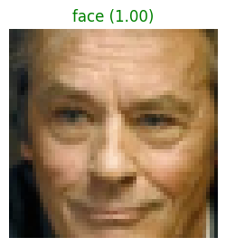

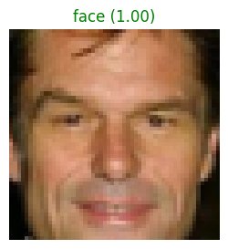

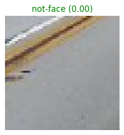

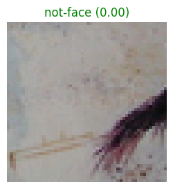

```python
indices = np.random.choice(len(X_test_cnn), 4, replace=False)
for idx in indices:
    plot_single_prediction_cnn(model_cnn, X_test_cnn, y_test, idx)
```

This CNN model didn't make any mistake in the classification. On the 4 random images we only have value of 1.0 and 0.0, so the model has a good precision.

## **6. Transfer Learning**

- Train a transfer learning model using any pre-trained model from the Keras API.
- Evaluate the performance of these models on the image classification task. Comment

your results.

- Save the validation and test scores for future comparison.

**1- Data preparation**

```python
import numpy as np
# Temporary X variable
X = np.load('X_images.npy')
Y_labels = np.load('Y_labels.npy')
print(X.shape)
```

```
(30000, 54, 54, 3)
```

**Transfer learning** allows us to leverage the feature extraction capabilities of a deep network that has already been trained on a large dataset like ImageNet. This is especially useful when our own dataset is limited in size or variety. We will freeze the base model to retain its learned features and add new layers on top to adapt it to our binary classification task (face vs. not-face).

```python
import numpy as np
from tensorflow.keras.utils import to_categorical
from sklearn.model_selection import train_test_split
from tensorflow.keras.applications import ResNet50
from tensorflow.keras import layers, models, Input
import tensorflow as tf


# Prepare labels (one-hot encoding)
num_classes = len(np.unique(Y_labels))
Y_labels_cat_learning = to_categorical(Y_labels, num_classes)

# Train/Validation/Test split
X_train_val_learning, X_test_learning, y_train_val_learning, y_test_learning = train_test_split(
    X, Y_labels_cat_learning, test_size=0.2, random_state=42)

X_train_learning, X_val_learning, y_train_learning, y_val_learning = train_test_split(
    X_train_val_learning, y_train_val_learning, test_size=0.2, random_state=42)

# Define ResNet50-based transfer learning model
input_shape = (54, 54, 3)
inputs = Input(shape=input_shape)
```

In this block, we prepare our data for use with a classification model that ends in a softmax layer by performing one-hot encoding on the labels. **One-hot encoding** is a technique that converts categorical labels into binary vectors, where each class is represented by a vector with a 1 in the position of the class index and 0s elsewhere.  
Since this is a binary classification task, the labels are transformed from values like 0 and 1 into categorical arrays like [1, 0] and [0, 1]. The dataset is split into training (64%), validation (16%), and test (20%) sets using train_test_split. This structure ensures proper evaluation and generalization.

**2- Building the transfer learning model with ResNet50 base**

```python
base_model = ResNet50(
    input_shape=input_shape,
    include_top=False,
    weights='imagenet'
)
base_model.trainable = False  # Freeze base layers

x = base_model(inputs, training=False)
x = layers.GlobalAveragePooling2D()(x)
x = layers.Dense(128, activation='relu')(x)
x = layers.Dropout(0.3)(x)
outputs = layers.Dense(num_classes, activation='softmax')(x)

model_learning = models.Model(inputs, outputs)

# Compile the model
model_learning.compile(
    optimizer='adam',
    loss='categorical_crossentropy',
    metrics=['accuracy']
)
```

Here we define a transfer learning model based on **ResNet50**, a powerful convolutional neural network pre-trained on ImageNet. We set include_top=False to remove the original classification head, so we can add our own layers adapted to the face detection task.

We freeze the ResNet base to prevent its weights from being updated during training, which saves time and avoids overfitting. Then, we add a **GlobalAveragePooling2D** layer to reduce the feature maps, followed by a Dense layer (128 units, ReLU), a Dropout layer (to prevent overfitting), and finally a Dense layer with softmax activation to produce probabilities for the two classes.

The model is compiled with the Adam optimizer, categorical crossentropy loss (since we use one-hot labels), and accuracy as the performance metric.

**3- Train the model**

```python
history_learning = model_learning.fit(
    X_train_learning, y_train_learning,
    validation_data=(X_val_learning, y_val_learning),
    epochs=20,
    batch_size=32
)
```

```
600/600 ━━━━━━━━━━━━━━━━━━━━ 26s 22ms/step - accuracy: 0.7137 - loss: 0.5633 - val_accuracy: 0.9054 - val_loss: 0.2615
600/600 ━━━━━━━━━━━━━━━━━━━━ 9s 15ms/step - accuracy: 0.9099 - loss: 0.2408 - val_accuracy: 0.9206 - val_loss: 0.2006
600/600 ━━━━━━━━━━━━━━━━━━━━ 10s 15ms/step - accuracy: 0.9256 - loss: 0.1983 - val_accuracy: 0.9173 - val_loss: 0.2182
600/600 ━━━━━━━━━━━━━━━━━━━━ 10s 15ms/step - accuracy: 0.9276 - loss: 0.1899 - val_accuracy: 0.9356 - val_loss: 0.1782
600/600 ━━━━━━━━━━━━━━━━━━━━ 9s 16ms/step - accuracy: 0.9362 - loss: 0.1726 - val_accuracy: 0.9379 - val_loss: 0.1660
600/600 ━━━━━━━━━━━━━━━━━━━━ 11s 16ms/step - accuracy: 0.9339 - loss: 0.1735 - val_accuracy: 0.9392 - val_loss: 0.1638
600/600 ━━━━━━━━━━━━━━━━━━━━ 9s 15ms/step - accuracy: 0.9378 - loss: 0.1644 - val_accuracy: 0.9354 - val_loss: 0.1608
600/600 ━━━━━━━━━━━━━━━━━━━━ 10s 17ms/step - accuracy: 0.9360 - loss: 0.1686 - val_accuracy: 0.9388 - val_loss: 0.1637
600/600 ━━━━━━━━━━━━━━━━━━━━ 9s 15ms/step - accuracy: 0.9391 - loss: 0.1579 - val_accuracy: 0.9296 - val_loss: 0.1800
600/600 ━━━━━━━━━━━━━━━━━━━━ 9s 16ms/step - accuracy: 0.9394 - loss: 0.1590 - val_accuracy: 0.9423 - val_loss: 0.1504
600/600 ━━━━━━━━━━━━━━━━━━━━ 9s 15ms/step - accuracy: 0.9438 - loss: 0.1487 - val_accuracy: 0.9206 - val_loss: 0.1987
600/600 ━━━━━━━━━━━━━━━━━━━━ 10s 17ms/step - accuracy: 0.9413 - loss: 0.1559 - val_accuracy: 0.9444 - val_loss: 0.1520
600/600 ━━━━━━━━━━━━━━━━━━━━ 9s 15ms/step - accuracy: 0.9456 - loss: 0.1467 - val_accuracy: 0.9394 - val_loss: 0.1678
600/600 ━━━━━━━━━━━━━━━━━━━━ 11s 17ms/step - accuracy: 0.9412 - loss: 0.1481 - val_accuracy: 0.9381 - val_loss: 0.1621
600/600 ━━━━━━━━━━━━━━━━━━━━ 9s 15ms/step - accuracy: 0.9494 - loss: 0.1385 - val_accuracy: 0.9260 - val_loss: 0.1878
600/600 ━━━━━━━━━━━━━━━━━━━━ 9s 16ms/step - accuracy: 0.9440 - loss: 0.1492 - val_accuracy: 0.9438 - val_loss: 0.1510
600/600 ━━━━━━━━━━━━━━━━━━━━ 10s 17ms/step - accuracy: 0.9453 - loss: 0.1451 - val_accuracy: 0.9450 - val_loss: 0.1515
600/600 ━━━━━━━━━━━━━━━━━━━━ 10s 17ms/step - accuracy: 0.9448 - loss: 0.1479 - val_accuracy: 0.9456 - val_loss: 0.1412
600/600 ━━━━━━━━━━━━━━━━━━━━ 10s 17ms/step - accuracy: 0.9477 - loss: 0.1397 - val_accuracy: 0.9465 - val_loss: 0.1370
600/600 ━━━━━━━━━━━━━━━━━━━━ 10s 17ms/step - accuracy: 0.9481 - loss: 0.1373 - val_accuracy: 0.9333 - val_loss: 0.1759
```

The loss values do not decrease linearly and seem to increase again at the end. So we will try to determine if we have overfitting.

**4- Evaluate the model**

```python
test_loss_learning, test_acc_learning = model_learning.evaluate(X_test_learning, y_test_learning)
print(f"Test accuracy: {test_acc_learning:.4f}")
```

```
188/188 ━━━━━━━━━━━━━━━━━━━━ 8s 25ms/step - accuracy: 0.9310 - loss: 0.1661
Test accuracy: 0.9350
```

**5- Do we have overfitting ?**

Visual representation of loss

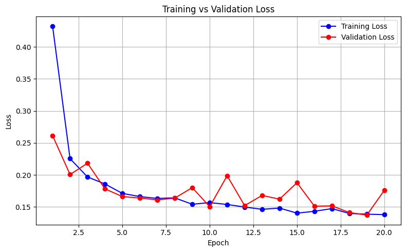

```python
import matplotlib.pyplot as plt
history = history_learning  # ou remplace par le tien

# Récupérer les valeurs
loss = history.history['loss']
val_loss = history.history['val_loss']
epochs = range(1, len(loss) + 1)

# Tracer les courbes
plt.figure(figsize=(8, 5))
plt.plot(epochs, loss, 'bo-', label='Training Loss')
plt.plot(epochs, val_loss, 'ro-', label='Validation Loss')
plt.title('Training vs Validation Loss')
plt.xlabel('Epoch')
plt.ylabel('Loss')
plt.legend()
plt.grid(True)
plt.tight_layout()
plt.show()
```

the loss function decreases nicely up to 12 epochs and then it seems to try to readapt at each epoch.

We are going to test with only 12 epochs to see if our model is adapting only on our train data.

```python
# One-hot encoding
num_classes_2 = len(np.unique(Y_labels))
Y_labels_cat_2 = to_categorical(Y_labels, num_classes_2)

# Train/val/test split
X_train_val_2, X_test_2, y_train_val_2, y_test_2 = train_test_split(
    X, Y_labels_cat_2, test_size=0.2, random_state=42)

X_train_2, X_val_2, y_train_2, y_val_2 = train_test_split(
    X_train_val_2, y_train_val_2, test_size=0.2, random_state=42)

# Model definition (new instance)
input_shape_2 = (54, 54, 3)
inputs_2 = Input(shape=input_shape_2)

base_model_2 = ResNet50(
    input_shape=input_shape_2,
    include_top=False,
    weights='imagenet'
)
base_model_2.trainable = False

x_2 = base_model_2(inputs_2, training=False)
x_2 = layers.GlobalAveragePooling2D()(x_2)
x_2 = layers.Dense(128, activation='relu')(x_2)
x_2 = layers.Dropout(0.3)(x_2)
outputs_2 = layers.Dense(num_classes_2, activation='softmax')(x_2)

model_learning_2 = models.Model(inputs_2, outputs_2)

model_learning_2.compile(
    optimizer='adam',
    loss='categorical_crossentropy',
    metrics=['accuracy']
)

# Train the new model with fewer epochs
history_learning_2 = model_learning_2.fit(
    X_train_2, y_train_2,
    validation_data=(X_val_2, y_val_2),
    epochs=12,
    batch_size=32
)
```

```
600/600 ━━━━━━━━━━━━━━━━━━━━ 24s 23ms/step - accuracy: 0.6981 - loss: 0.5730 - val_accuracy: 0.9058 - val_loss: 0.2633
600/600 ━━━━━━━━━━━━━━━━━━━━ 10s 17ms/step - accuracy: 0.9124 - loss: 0.2437 - val_accuracy: 0.9227 - val_loss: 0.2049
600/600 ━━━━━━━━━━━━━━━━━━━━ 10s 16ms/step - accuracy: 0.9234 - loss: 0.1969 - val_accuracy: 0.9315 - val_loss: 0.1848
600/600 ━━━━━━━━━━━━━━━━━━━━ 10s 17ms/step - accuracy: 0.9300 - loss: 0.1834 - val_accuracy: 0.9244 - val_loss: 0.2005
600/600 ━━━━━━━━━━━━━━━━━━━━ 10s 17ms/step - accuracy: 0.9365 - loss: 0.1687 - val_accuracy: 0.9275 - val_loss: 0.1914
600/600 ━━━━━━━━━━━━━━━━━━━━ 9s 15ms/step - accuracy: 0.9353 - loss: 0.1702 - val_accuracy: 0.9225 - val_loss: 0.1852
600/600 ━━━━━━━━━━━━━━━━━━━━ 9s 15ms/step - accuracy: 0.9366 - loss: 0.1630 - val_accuracy: 0.9398 - val_loss: 0.1577
600/600 ━━━━━━━━━━━━━━━━━━━━ 9s 15ms/step - accuracy: 0.9351 - loss: 0.1704 - val_accuracy: 0.9356 - val_loss: 0.1588
600/600 ━━━━━━━━━━━━━━━━━━━━ 10s 15ms/step - accuracy: 0.9400 - loss: 0.1581 - val_accuracy: 0.9413 - val_loss: 0.1508
600/600 ━━━━━━━━━━━━━━━━━━━━ 10s 17ms/step - accuracy: 0.9408 - loss: 0.1530 - val_accuracy: 0.9402 - val_loss: 0.1617
600/600 ━━━━━━━━━━━━━━━━━━━━ 9s 15ms/step - accuracy: 0.9429 - loss: 0.1496 - val_accuracy: 0.9431 - val_loss: 0.1530
600/600 ━━━━━━━━━━━━━━━━━━━━ 9s 15ms/step - accuracy: 0.9383 - loss: 0.1525 - val_accuracy: 0.9423 - val_loss: 0.1517
```

```python
# Evaluate
test_loss_learning_2, test_acc_learning_2 = model_learning_2.evaluate(X_test_2, y_test_2)
print(f"\nTest accuracy (second training): {test_acc_learning_2:.4f}")
```

```
188/188 ━━━━━━━━━━━━━━━━━━━━ 8s 20ms/step - accuracy: 0.9456 - loss: 0.1430

Test accuracy (second training): 0.9488
```

New loss representation

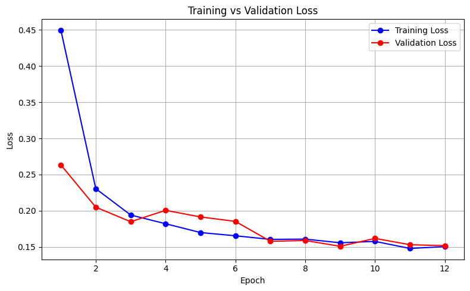

```python
import matplotlib.pyplot as plt
history = history_learning_2

# Récupérer les valeurs
loss = history.history['loss']
val_loss = history.history['val_loss']
epochs = range(1, len(loss) + 1)

# Tracer les courbes
plt.figure(figsize=(8, 5))
plt.plot(epochs, loss, 'bo-', label='Training Loss')
plt.plot(epochs, val_loss, 'ro-', label='Validation Loss')
plt.title('Training vs Validation Loss')
plt.xlabel('Epoch')
plt.ylabel('Loss')
plt.legend()
plt.grid(True)
plt.tight_layout()
plt.show()
```

```python
import json

learning_2_scores = {
    "test_accuracy_2": test_acc_learning_2,
    "test_loss_2": test_loss_learning_2,
    "val_accuracy_last_epoch_2": history_learning_2.history["val_accuracy"][-1],
    "train_accuracy_last_epoch_2": history_learning_2.history["accuracy"][-1],
}

with open("learning_2_scores.json", "w") as f:
    json.dump(learning_2_scores, f)
```

## **7. Semi-supervised Learning**

In this part, we implemented a semi-supervised learning strategy to use labeled data and unlabeled data. Here are the steps of this part :

- Train a Variational Autoencoder (VAE) using 70% of the data. The VAE should have a latent space of dimension 20.
- Visualize the latent space using the 20% of the data allocated for supervised learning.
- Couple the encoder part of the trained VAE with: A neural network, An XGBoost model
- Perform transfer learning by training only the newly added parts (the neural network and XGBoost) on the 20% supervised data.
- Evaluate the performance of each model (VAE + neural network and VAE + XGBoost) on the validation and test sets.
- Save the validation and test scores of each model for future comparison.
- Perform fine-tuning by training the entire model (VAE encoder and the newly added parts) for both the neural network and XGBoost on the 20% supervised data.
- Evaluate the performance of each fine-tuned model (VAE + neural network and VAE + XGBoost) on the validation and test sets.
- Save the validation and test scores of each fine-tuned model for future comparison.

**7.1 Train a Variational Autoencoder**

```python
# Import necessary module to build and train the VAE
from sklearn.model_selection import train_test_split
from tensorflow.keras import layers
from tensorflow import keras
import tensorflow as tf
```

First we define a custom Sampling layer, which takes as input the latent space parameters (z_mean and z_log_var) and generates a random vector z by sampling from the Gaussian distribution. This sampling allows the VAE to learn a continuous latent representation of the input data.

```python
#Create a sampling layer
class Sampling(layers.Layer):
  def call(self, inputs):
    z_mean, z_log_var = inputs
    epsilon = tf.random.normal(shape=tf.shape(z_mean))
    return z_mean + tf.exp(0.5 * z_log_var) * epsilon
```

Next, we build the VAE using, for the encoder which will map input images to their latent representations :

- 3 convolutional layers, which will extract features from the input image, with 32, 64 and 128 filters (3x3) and the relu activation function.
- 2 Batch Normalization layers to ensure the normal distribution after each convolutional layer. It acts as regularization of the latent space by ensuring that z_mean and z_log are based on coherent features. Also, it stabilizes and speeds up the training.
- Then we flatten the resulting 3D features in 1D vector compatible with the dense layers.
- 1 Dense layer to process the features and 2 Dense layers that output z_mean and z_log_var
- z_mean and z_log_var are passed through the Sampling layer to produce the vector z

```python
latent_dim = 20
```

```python
#Encoder
encoder_inputs = keras.Input(shape=(54,54,3))
x = layers.Conv2D(32,3,strides=2, activation='relu', padding='same')(encoder_inputs)
x = layers.BatchNormalization()(x)
x = layers.Conv2D(64, 3, strides=2, activation='relu',padding='same')(x)
x = layers.BatchNormalization()(x)
x = layers.Conv2D(128, 3, strides=2, activation='relu', padding='same')(x)
x = layers.Flatten()(x)
x = layers.Dense(128, activation='relu')(x)
z_mean = layers.Dense(latent_dim)(x)
z_log_var = layers.Dense(latent_dim)(x)
z = Sampling()([z_mean, z_log_var])
encoder = keras.Model(encoder_inputs, [z_mean, z_log_var, z], name='encoder')
```

For the decoder which will reconstruct the images from their latent representation :

- 1 Dense layer that takes latent vector z as input with relu activation function
- The output is reshaped for the reconstruction
- 3 Convolutional 2D Transpose layers with 128, 64 and 32 filters (3x3) which upsample back the original shape (54, 54, 3) using the low dimension z vector from the latent space
- 1 Cropping layer to ensure that the output image has the correct dimensions (54x54) after upsampling
- 1 last Convolutional 2D Transpose layer with 3 filters (3x3) for the 3 color channels with a sigmoid activation function to make sure that output image is well normalized with pixel values between 0 and 1 included.

```python
# Decoder
latent_inputs = keras.Input(shape=(latent_dim,))
x = layers.Dense(7*7*128, activation='relu')(latent_inputs)
x = layers.Reshape((7,7,128))(x)
x = layers.Conv2DTranspose(128,3,strides=2, activation='relu', padding='same')(x)
x = layers.Conv2DTranspose(64,3,strides=2, activation='relu', padding='same')(x)
x = layers.Conv2DTranspose(32,3,strides=2, activation='relu', padding='same')(x)
x = layers.Cropping2D(((1,1),(1,1)))(x)
decoder_outputs = layers.Conv2DTranspose(3,3,activation='sigmoid', padding='same')(x)
decoder = keras.Model(latent_inputs, decoder_outputs, name='decoder')
```

The VAE model is then defined with the encoder part, the decoder part and some metrics to evaluate the reconstruction sloss. In fact, we compute the reconstruction loss (between the input and reconstructed image) and the Kullback-Leibler (KL) divergence, which ensures the latent space remains close to a standard normal distribution. The two losses are combined and used to update the weights during training.

```python
# Define the VAE as a Model with a custom train_step
class VAE(keras.Model):
    def __init__(self, encoder, decoder, beta=4.0, **kwargs):
        super().__init__(**kwargs)
        self.encoder = encoder
        self.decoder = decoder
        self.beta = beta
        self.total_loss_tracker = keras.metrics.Mean(name="total_loss")
        self.reconstruction_loss_tracker = keras.metrics.Mean(name="reconstruction_loss")
        self.kl_loss_tracker = keras.metrics.Mean(name="kl_loss")

    def call(self, inputs):
        z_mean, z_log_var, z = self.encoder(inputs)
        return self.decoder(z)

    def train_step(self, data):
        with tf.GradientTape() as tape:
            z_mean, z_log_var, z = self.encoder(data)
            reconstruction = self.decoder(z)
            reconstruction_loss = tf.reduce_mean(tf.reduce_sum(keras.losses.binary_crossentropy(data, reconstruction), axis=(1, 2)))
            kl_loss = -0.5 * tf.reduce_mean(
                tf.reduce_sum(1 + z_log_var - tf.square(z_mean) - tf.exp(z_log_var), axis=1)
            )
            total_loss = reconstruction_loss + self.beta * kl_loss

        grads = tape.gradient(total_loss, self.trainable_weights)
        self.optimizer.apply_gradients(zip(grads, self.trainable_weights))
        self.total_loss_tracker.update_state(total_loss)
        self.reconstruction_loss_tracker.update_state(reconstruction_loss)
        self.kl_loss_tracker.update_state(kl_loss)

        return {
            "loss": self.total_loss_tracker.result(),
            "reconstruction_loss": self.reconstruction_loss_tracker.result(),
            "kl_loss": self.kl_loss_tracker.result(),
        }
```

```python
from sklearn.model_selection import train_test_split

# 70% unsupervised (VAE)
X_trainval_vae, X_test_vae, y_trainval_vae, y_test_vae = train_test_split(X_images, Y_labels, test_size=0.2)

# 20% supervised + 10% test
X_train_vae, X_val_vae, y_train_vae, y_val_vae = train_test_split(X_trainval_vae, y_trainval_vae, test_size=0.1)
```

We add an Early Stopping component so that we avoid overfitting while training the model. We choose a patience of 3 here.

```python
early_stop = keras.callbacks.EarlyStopping(monitor='loss', patience=3, restore_best_weights=True)
```

The VAE is trained for 20 epochs using 70% of the data.

```python
# Train the VAE

# Define VAE
vae = VAE(encoder,decoder)
vae.compile(optimizer=keras.optimizers.Adam(), loss=None, run_eagerly=True)

# Train VAE
vae.fit(X_train_vae, epochs=20, batch_size=54, callbacks=[early_stop])
```

```
400/400 ━━━━━━━━━━━━━━━━━━━━ 71s 175ms/step - kl_loss: 4.0511 - loss: 1902.8688 - reconstruction_loss: 1886.6647
400/400 ━━━━━━━━━━━━━━━━━━━━ 81s 176ms/step - kl_loss: 8.3362 - loss: 1769.7349 - reconstruction_loss: 1736.3896
400/400 ━━━━━━━━━━━━━━━━━━━━ 82s 176ms/step - kl_loss: 8.8988 - loss: 1751.1044 - reconstruction_loss: 1715.5095
400/400 ━━━━━━━━━━━━━━━━━━━━ 82s 177ms/step - kl_loss: 9.3486 - loss: 1741.6587 - reconstruction_loss: 1704.2643
400/400 ━━━━━━━━━━━━━━━━━━━━ 70s 175ms/step - kl_loss: 9.6696 - loss: 1740.4038 - reconstruction_loss: 1701.7253
400/400 ━━━━━━━━━━━━━━━━━━━━ 71s 176ms/step - kl_loss: 9.9960 - loss: 1739.9292 - reconstruction_loss: 1699.9447
400/400 ━━━━━━━━━━━━━━━━━━━━ 82s 176ms/step - kl_loss: 10.1083 - loss: 1735.9690 - reconstruction_loss: 1695.5354
400/400 ━━━━━━━━━━━━━━━━━━━━ 82s 177ms/step - kl_loss: 10.4440 - loss: 1732.6259 - reconstruction_loss: 1690.8501
400/400 ━━━━━━━━━━━━━━━━━━━━ 71s 177ms/step - kl_loss: 10.5577 - loss: 1732.2028 - reconstruction_loss: 1689.9723
400/400 ━━━━━━━━━━━━━━━━━━━━ 71s 177ms/step - kl_loss: 10.6158 - loss: 1730.5330 - reconstruction_loss: 1688.0698
400/400 ━━━━━━━━━━━━━━━━━━━━ 81s 175ms/step - kl_loss: 10.6261 - loss: 1731.6987 - reconstruction_loss: 1689.1937
400/400 ━━━━━━━━━━━━━━━━━━━━ 82s 176ms/step - kl_loss: 10.7021 - loss: 1729.0604 - reconstruction_loss: 1686.2524
400/400 ━━━━━━━━━━━━━━━━━━━━ 82s 176ms/step - kl_loss: 10.7043 - loss: 1727.7858 - reconstruction_loss: 1684.9683
400/400 ━━━━━━━━━━━━━━━━━━━━ 82s 176ms/step - kl_loss: 10.8108 - loss: 1727.5994 - reconstruction_loss: 1684.3567
400/400 ━━━━━━━━━━━━━━━━━━━━ 82s 176ms/step - kl_loss: 10.9373 - loss: 1727.5226 - reconstruction_loss: 1683.7736
400/400 ━━━━━━━━━━━━━━━━━━━━ 82s 175ms/step - kl_loss: 10.9535 - loss: 1726.4443 - reconstruction_loss: 1682.6305
400/400 ━━━━━━━━━━━━━━━━━━━━ 73s 182ms/step - kl_loss: 11.0216 - loss: 1728.6841 - reconstruction_loss: 1684.5979
400/400 ━━━━━━━━━━━━━━━━━━━━ 77s 193ms/step - kl_loss: 10.9749 - loss: 1727.6127 - reconstruction_loss: 1683.7133
400/400 ━━━━━━━━━━━━━━━━━━━━ 70s 176ms/step - kl_loss: 11.0207 - loss: 1722.4082 - reconstruction_loss: 1678.3253
400/400 ━━━━━━━━━━━━━━━━━━━━ 72s 179ms/step - kl_loss: 11.0129 - loss: 1727.2601 - reconstruction_loss: 1683.2084
```

```
<keras.src.callbacks.history.History at 0x7c93b1f39050>
```

After the las epoch of training. The KL divergence loss (kl_loss) which measures how much the learned latent distribution diverges from a standard normal distribution is equal to 11.0129. This value is not close to zero, indicating that the model’s latent space does not perfectly follow a standard normal distribution, which can make it harder to generate quality samples in the latent space.

The reconstruction_loss that measures how well the decoder manages to rebuild the original image from its compressed latent representation is equal to 1683.2084. This value is high. This suggests that the reconstructions can be a bit far from the original images, either because the model has not fully learned the features.

```
45/45 ━━━━━━━━━━━━━━━━━━━━ 3s 24ms/step
```

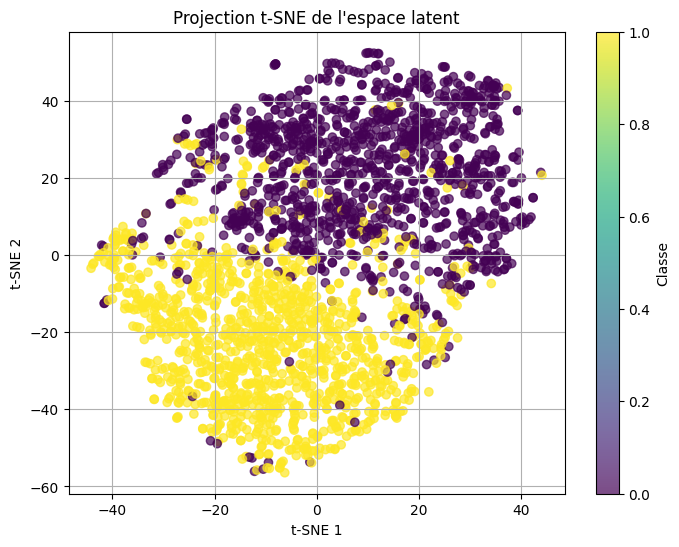

```python
from sklearn.manifold import TSNE
import matplotlib.pyplot as plt

X_sup = X_val_vae
y_sup = y_val_vae

# Obtenir la représentation latente (z_mean) depuis l'encodeur
z_mean, _, _ = encoder.predict(X_sup, batch_size=54)

# Réduction de dimension avec t-SNE
latent_2d = TSNE(n_components=2, perplexity=30, random_state=42).fit_transform(z_mean)

# Affichage
plt.figure(figsize=(8,6))
scatter = plt.scatter(latent_2d[:,0], latent_2d[:,1], c=y_sup, cmap='viridis', alpha=0.7)
plt.colorbar(scatter, label='Classe')
plt.title('Projection t-SNE de l\'espace latent')
plt.xlabel('t-SNE 1')
plt.ylabel('t-SNE 2')
plt.grid(True)
plt.show()
```

This visualization shows that the encoder’s latent features reflect class structure, despite being learned without labels. It confirms that the VAE has captured meaningful patterns through unsupervised learning.

**7.3 Couple the encoder part of the trained VAE with: A neural network, An XGBoost model**

The purpose of this part is to use the latent output in order to perform classification of images using two methods : Neural Netwrok and XGBoost model.

The Neural Network model is a simple baseline model without convolutional layers.

The XGBoost algorithm is a supervised model based on decision trees and work similarly as Random Forst but it builds many subtrees, and each new tree corrects the errors of the previous ones. This process is called boosting.

First we split the data and verify the size of each subset.

```python
from sklearn.model_selection import train_test_split

# First split : train+val vs test (80% / 20%)
X_trainval_vae, X_test_vae, y_trainval_vae, y_test_vae = train_test_split(
    X_images, Y_labels, test_size=0.2, random_state=42
)

# Second split : train vs val (90% / 10%)
X_train_vae, X_val_vae, y_train_vae, y_val_vae = train_test_split(
    X_trainval_vae, y_trainval_vae, test_size=0.1, random_state=42
)

# Vérification des tailles
print(f"X_train_vae: {X_train_vae.shape}, y_train_vae: {y_train_vae.shape}")
print(f"X_val_vae: {X_val_vae.shape}, y_val_vae: {y_val_vae.shape}")
print(f"X_test_vae: {X_test_vae.shape}, y_test_vae: {y_test_vae.shape}")
```

```
X_train_vae: (21600, 54, 54, 3), y_train_vae: (21600, 1)
X_val_vae: (2400, 54, 54, 3), y_val_vae: (2400, 1)
X_test_vae: (6000, 54, 54, 3), y_test_vae: (6000, 1)
```

**VAE with a Neural Network**

The neural network model consists of :

- 1 Hidden Dense layer with 64 neurons and relu activation
- 1 Output layer with one neuron and sigmoid activation for the binary classification result

```python
# Extraction des représentations latentes (z_mean) sur les données d'entraînement supervisées
z_mean_train, _, _ = encoder.predict(X_train_vae, batch_size=54)

# Création du classifieur sur l'espace latent
nn_model = Sequential([
    Dense(64, activation='relu', input_shape=(z_mean_train.shape[1],)),
    Dense(1, activation='sigmoid')  # pour classification binaire
])

nn_model.compile(optimizer='adam', loss='binary_crossentropy', metrics=['accuracy'])

# Entraînement du classifieur
history_nn = nn_model.fit(
    z_mean_train,
    y_train_vae,
    epochs=20,
    validation_data=(
        encoder.predict(X_val_vae, batch_size=54)[0],  # z_mean_val
        y_val_vae
    ),
    batch_size=32
)
```

```
400/400 ━━━━━━━━━━━━━━━━━━━━ 1s 2ms/step
```

```
45/45 ━━━━━━━━━━━━━━━━━━━━ 0s 2ms/step
675/675 ━━━━━━━━━━━━━━━━━━━━ 4s 4ms/step - accuracy: 0.9104 - loss: 0.3099 - val_accuracy: 0.9592 - val_loss: 0.1101
675/675 ━━━━━━━━━━━━━━━━━━━━ 2s 2ms/step - accuracy: 0.9641 - loss: 0.1018 - val_accuracy: 0.9633 - val_loss: 0.1002
675/675 ━━━━━━━━━━━━━━━━━━━━ 3s 2ms/step - accuracy: 0.9681 - loss: 0.0889 - val_accuracy: 0.9646 - val_loss: 0.0949
675/675 ━━━━━━━━━━━━━━━━━━━━ 3s 3ms/step - accuracy: 0.9703 - loss: 0.0842 - val_accuracy: 0.9658 - val_loss: 0.0948
675/675 ━━━━━━━━━━━━━━━━━━━━ 2s 3ms/step - accuracy: 0.9690 - loss: 0.0857 - val_accuracy: 0.9692 - val_loss: 0.0928
675/675 ━━━━━━━━━━━━━━━━━━━━ 2s 3ms/step - accuracy: 0.9723 - loss: 0.0821 - val_accuracy: 0.9658 - val_loss: 0.0928
675/675 ━━━━━━━━━━━━━━━━━━━━ 2s 3ms/step - accuracy: 0.9707 - loss: 0.0861 - val_accuracy: 0.9688 - val_loss: 0.0917
675/675 ━━━━━━━━━━━━━━━━━━━━ 2s 2ms/step - accuracy: 0.9708 - loss: 0.0817 - val_accuracy: 0.9667 - val_loss: 0.0944
675/675 ━━━━━━━━━━━━━━━━━━━━ 2s 2ms/step - accuracy: 0.9714 - loss: 0.0794 - val_accuracy: 0.9683 - val_loss: 0.0933
675/675 ━━━━━━━━━━━━━━━━━━━━ 2s 2ms/step - accuracy: 0.9727 - loss: 0.0804 - val_accuracy: 0.9671 - val_loss: 0.0938
675/675 ━━━━━━━━━━━━━━━━━━━━ 2s 3ms/step - accuracy: 0.9735 - loss: 0.0782 - val_accuracy: 0.9671 - val_loss: 0.0947
675/675 ━━━━━━━━━━━━━━━━━━━━ 2s 2ms/step - accuracy: 0.9714 - loss: 0.0813 - val_accuracy: 0.9679 - val_loss: 0.0937
675/675 ━━━━━━━━━━━━━━━━━━━━ 3s 4ms/step - accuracy: 0.9732 - loss: 0.0765 - val_accuracy: 0.9675 - val_loss: 0.0929
675/675 ━━━━━━━━━━━━━━━━━━━━ 2s 2ms/step - accuracy: 0.9749 - loss: 0.0740 - val_accuracy: 0.9675 - val_loss: 0.0942
675/675 ━━━━━━━━━━━━━━━━━━━━ 3s 3ms/step - accuracy: 0.9729 - loss: 0.0779 - val_accuracy: 0.9671 - val_loss: 0.0926
675/675 ━━━━━━━━━━━━━━━━━━━━ 2s 2ms/step - accuracy: 0.9741 - loss: 0.0747 - val_accuracy: 0.9683 - val_loss: 0.0934
675/675 ━━━━━━━━━━━━━━━━━━━━ 2s 3ms/step - accuracy: 0.9751 - loss: 0.0740 - val_accuracy: 0.9683 - val_loss: 0.0937
675/675 ━━━━━━━━━━━━━━━━━━━━ 2s 3ms/step - accuracy: 0.9753 - loss: 0.0726 - val_accuracy: 0.9683 - val_loss: 0.0938
675/675 ━━━━━━━━━━━━━━━━━━━━ 3s 3ms/step - accuracy: 0.9722 - loss: 0.0794 - val_accuracy: 0.9654 - val_loss: 0.0970
675/675 ━━━━━━━━━━━━━━━━━━━━ 2s 3ms/step - accuracy: 0.9696 - loss: 0.0826 - val_accuracy: 0.9671 - val_loss: 0.0934
```

**VAE with an XGBoost model**

An XGBoost classifier is trained on the latent features (z_mean) extracted from the VAE encoder. These features are used as input to the model, with the labels flattened using .ravel() to match the expected format. The model is set to optimize the logarithmic loss (logloss), which is used for binary classification. This approach evaluates how well the VAE latent space can support non-neural classifiers like XGBoost.

```python
import xgboost as xgb

# Extraction des représentations latentes (z_mean) sur les données supervisées
z_mean_train, _, _ = encoder.predict(X_train_vae, batch_size=54)

# Création du modèle XGBoost
xgb_model = xgb.XGBClassifier(use_label_encoder=False, eval_metric='logloss')

# Entraînement sur les latents
xgb_model.fit(z_mean_train, y_train_vae.ravel())  # .ravel() pour avoir un vecteur 1D de labels
```

```
400/400 ━━━━━━━━━━━━━━━━━━━━ 1s 2ms/step
```

```
XGBClassifier(base_score=None, booster=None, callbacks=None,
              colsample_bylevel=None, colsample_bynode=None,
              colsample_bytree=None, device=None, early_stopping_rounds=None,
              enable_categorical=False, eval_metric='logloss',
              feature_types=None, gamma=None, grow_policy=None,
              importance_type=None, interaction_constraints=None,
              learning_rate=None, max_bin=None, max_cat_threshold=None,
              max_cat_to_onehot=None, max_delta_step=None, max_depth=None,
              max_leaves=None, min_child_weight=None, missing=nan,
              monotone_constraints=None, multi_strategy=None, n_estimators=None,
              n_jobs=None, num_parallel_tree=None, random_state=None, ...)
```

**7.4 Perform transfer learning by training only the newly added parts (the neural network and XGBoost) on the 20% supervised data.**

In this part, the encoder is frozen and we only train the two other model for the classification task using the latent vectors.

We split the data and extract the z_mean to get test data.

```python
from sklearn.model_selection import train_test_split

# 20% des données d'entraînement pour la supervision
X_sup_train, _, y_sup_train, _ = train_test_split(
    X_train_vae, y_train_vae, test_size=0.8, random_state=42
)
# Extraction de z_mean (représentation latente) pour les données supervisées
latent_sup = encoder.predict(X_sup_train, batch_size=54)
if isinstance(latent_sup, list):
    latent_sup = latent_sup[0]

# Extraction de z_mean pour les données de test
latent_test = encoder.predict(X_test_vae, batch_size=54)
if isinstance(latent_test, list):
    latent_test = latent_test[0]
```

```
80/80 ━━━━━━━━━━━━━━━━━━━━ 1s 7ms/step
112/112 ━━━━━━━━━━━━━━━━━━━━ 2s 17ms/step
```

**Transfer Learning with Neural Network**

```python
from tensorflow.keras import Sequential
from tensorflow.keras.layers import Dense

# Modèle NN sur espace latent
nn_model = Sequential([
    Dense(64, activation='relu', input_shape=(latent_sup.shape[1],)),
    Dense(1, activation='sigmoid')
])

nn_model.compile(optimizer='adam', loss='binary_crossentropy', metrics=['accuracy'])

# Entraînement uniquement sur les données supervisées (20%)
history_nn = nn_model.fit(
    latent_sup, y_sup_train,
    epochs=20,
    batch_size=32,
    validation_split=0.2
)
```

```
108/108 ━━━━━━━━━━━━━━━━━━━━ 3s 6ms/step - accuracy: 0.7346 - loss: 0.5839 - val_accuracy: 0.9595 - val_loss: 0.3154
108/108 ━━━━━━━━━━━━━━━━━━━━ 2s 5ms/step - accuracy: 0.9447 - loss: 0.2778 - val_accuracy: 0.9676 - val_loss: 0.1735
108/108 ━━━━━━━━━━━━━━━━━━━━ 1s 5ms/step - accuracy: 0.9576 - loss: 0.1670 - val_accuracy: 0.9745 - val_loss: 0.1276
108/108 ━━━━━━━━━━━━━━━━━━━━ 0s 4ms/step - accuracy: 0.9474 - loss: 0.1381 - val_accuracy: 0.9745 - val_loss: 0.1100
108/108 ━━━━━━━━━━━━━━━━━━━━ 1s 3ms/step - accuracy: 0.9622 - loss: 0.1153 - val_accuracy: 0.9699 - val_loss: 0.1049
108/108 ━━━━━━━━━━━━━━━━━━━━ 0s 4ms/step - accuracy: 0.9573 - loss: 0.1147 - val_accuracy: 0.9757 - val_loss: 0.0954
108/108 ━━━━━━━━━━━━━━━━━━━━ 0s 3ms/step - accuracy: 0.9674 - loss: 0.1010 - val_accuracy: 0.9792 - val_loss: 0.0919
108/108 ━━━━━━━━━━━━━━━━━━━━ 1s 5ms/step - accuracy: 0.9614 - loss: 0.1095 - val_accuracy: 0.9792 - val_loss: 0.0896
108/108 ━━━━━━━━━━━━━━━━━━━━ 0s 4ms/step - accuracy: 0.9600 - loss: 0.0970 - val_accuracy: 0.9803 - val_loss: 0.0864
108/108 ━━━━━━━━━━━━━━━━━━━━ 1s 5ms/step - accuracy: 0.9631 - loss: 0.0999 - val_accuracy: 0.9815 - val_loss: 0.0846
108/108 ━━━━━━━━━━━━━━━━━━━━ 1s 5ms/step - accuracy: 0.9695 - loss: 0.0874 - val_accuracy: 0.9757 - val_loss: 0.0843
108/108 ━━━━━━━━━━━━━━━━━━━━ 1s 5ms/step - accuracy: 0.9703 - loss: 0.0946 - val_accuracy: 0.9757 - val_loss: 0.0820
108/108 ━━━━━━━━━━━━━━━━━━━━ 1s 5ms/step - accuracy: 0.9641 - loss: 0.0911 - val_accuracy: 0.9826 - val_loss: 0.0816
108/108 ━━━━━━━━━━━━━━━━━━━━ 1s 5ms/step - accuracy: 0.9670 - loss: 0.0901 - val_accuracy: 0.9792 - val_loss: 0.0802
108/108 ━━━━━━━━━━━━━━━━━━━━ 1s 7ms/step - accuracy: 0.9722 - loss: 0.0765 - val_accuracy: 0.9792 - val_loss: 0.0808
108/108 ━━━━━━━━━━━━━━━━━━━━ 1s 5ms/step - accuracy: 0.9692 - loss: 0.0821 - val_accuracy: 0.9792 - val_loss: 0.0819
108/108 ━━━━━━━━━━━━━━━━━━━━ 1s 5ms/step - accuracy: 0.9654 - loss: 0.0922 - val_accuracy: 0.9769 - val_loss: 0.0806
108/108 ━━━━━━━━━━━━━━━━━━━━ 0s 4ms/step - accuracy: 0.9702 - loss: 0.0824 - val_accuracy: 0.9815 - val_loss: 0.0783
108/108 ━━━━━━━━━━━━━━━━━━━━ 1s 4ms/step - accuracy: 0.9708 - loss: 0.0928 - val_accuracy: 0.9769 - val_loss: 0.0796
108/108 ━━━━━━━━━━━━━━━━━━━━ 0s 3ms/step - accuracy: 0.9699 - loss: 0.0878 - val_accuracy: 0.9780 - val_loss: 0.0798
```

A simple neural network classifier was trained on the latent features (z_mean) produced by the VAE encoder. After 20 epochs, it achieved a training accuracy of 96.99% and a validation accuracy of 97.80%. This indicates that the transfer learning worked well and th latent space contains meaningful and easily separable information for class prediction.

**Transfer Learning with XGBoost**

```python
import xgboost as xgb

# Création du modèle XGBoost
xgb_model = xgb.XGBClassifier(use_label_encoder=False, eval_metric='logloss')

# Entraînement uniquement sur les données supervisées (20%)
xgb_model.fit(latent_sup, y_sup_train.ravel())  # .ravel() pour forme 1D des labels
```

```
XGBClassifier(base_score=None, booster=None, callbacks=None,
              colsample_bylevel=None, colsample_bynode=None,
              colsample_bytree=None, device=None, early_stopping_rounds=None,
              enable_categorical=False, eval_metric='logloss',
              feature_types=None, gamma=None, grow_policy=None,
              importance_type=None, interaction_constraints=None,
              learning_rate=None, max_bin=None, max_cat_threshold=None,
              max_cat_to_onehot=None, max_delta_step=None, max_depth=None,
              max_leaves=None, min_child_weight=None, missing=nan,
              monotone_constraints=None, multi_strategy=None, n_estimators=None,
              n_jobs=None, num_parallel_tree=None, random_state=None, ...)
```

**7.5 Evaluate the performance of each model (VAE + neural network and VAE + XGBoost) on the validation and test sets.**

```python
# Extraction latents validation si besoin
latent_val, _, _ = encoder.predict(X_val_vae, batch_size=54)
if isinstance(latent_val, list):
    latent_val = latent_val[0]

# --- Évaluation Neural Network ---
print("Evaluation Neural Network:")
nn_val_loss, nn_val_acc = nn_model.evaluate(latent_val, y_val_vae, verbose=0)
nn_test_loss, nn_test_acc = nn_model.evaluate(latent_test, y_test_vae, verbose=0)
print(f"NN validation accuracy: {nn_val_acc:.4f}")
print(f"NN test accuracy:       {nn_test_acc:.4f}")

# --- Évaluation XGBoost ---
print("\nEvaluation XGBoost:")
xgb_val_acc = xgb_model.score(latent_val, y_val_vae.ravel())
xgb_test_acc = xgb_model.score(latent_test, y_test_vae.ravel())
print(f"XGBoost validation accuracy: {xgb_val_acc:.4f}")
print(f"XGBoost test accuracy:       {xgb_test_acc:.4f}")
```

```
45/45 ━━━━━━━━━━━━━━━━━━━━ 0s 5ms/step
Evaluation Neural Network:
NN validation accuracy: 0.9608
NN test accuracy:       0.9615

Evaluation XGBoost:
XGBoost validation accuracy: 0.9583
XGBoost test accuracy:       0.9610
```

The neural network achieved a validation accuracy of 96.08% and a test accuracy of 96.15% after transfer learning, indicating strong performance. The XGBoost model performed very similarly, with a validation accuracy of 95.83% and test accuracy of 96.10%.

These results show that the two models are able to classify the data correctly based on the VAE’s latent representation. The small difference in accuracy shows that the neural network barely outperforms the XGBoost model. It may be because the NN better captures the structure of continuous latent features than XGBoost.

**7.6 Save the validation and test scores of each model for future comparison.**

```python
import json
transfer_scores_vae2 = {
    'VAE+NN_val_acc': nn_val_acc,
    'VAE+NN_test_acc': nn_test_acc,
    'VAE+XGB_val_acc': xgb_val_acc,
    'VAE+XGB_test_acc': xgb_test_acc
}

with open("transfer_scores_vae2.json", "w") as f:
    json.dump(transfer_scores_vae2, f)
```

**7.7 Perform fine-tuning by training the entire model (VAE encoder and the newly added parts) for both the neural network and XGBoost on the 20% supervised data.**

n this part, we perform fine-tuning by training the entire model (VAE encoder and the neural network classifier or XGBoost model) on the 20% supervised data. Instead of freezing the encoder, the gradient of the latent space can be updated in order to adapt specifically to the classification task. The model is trained for 20 epochs.

**Fine-tuning with Neural Network**

```python
from tensorflow.keras import Model, Input
from tensorflow.keras.layers import Dense

# Reshape X_sup_train si besoin
X_sup_train = X_sup_train.reshape(-1, 54, 54, 3)

# Input images
input_img = Input(shape=(54, 54, 3))

# Encoder renvoie [z_mean, z_log_var, z]
z_mean, _, _ = encoder(input_img)

# Classifieur ajouté sur z_mean
x = Dense(64, activation='relu')(z_mean)
output = Dense(1, activation='sigmoid')(x)

# Modèle complet pour fine-tuning
finetune_model = Model(inputs=input_img, outputs=output)

finetune_model.compile(optimizer='adam', loss='binary_crossentropy', metrics=['accuracy'])
```

```python
history_finetune = finetune_model.fit(
    X_sup_train, y_sup_train,
    epochs=20,
    batch_size=32,
    validation_split=0.2
)
```

```
108/108 ━━━━━━━━━━━━━━━━━━━━ 7s 13ms/step - accuracy: 0.8474 - loss: 0.7591 - val_accuracy: 0.5127 - val_loss: 1.4526
108/108 ━━━━━━━━━━━━━━━━━━━━ 1s 6ms/step - accuracy: 0.9841 - loss: 0.0556 - val_accuracy: 0.5243 - val_loss: 1.9199
108/108 ━━━━━━━━━━━━━━━━━━━━ 1s 6ms/step - accuracy: 0.9899 - loss: 0.0336 - val_accuracy: 0.8611 - val_loss: 0.2748
108/108 ━━━━━━━━━━━━━━━━━━━━ 1s 6ms/step - accuracy: 0.9976 - loss: 0.0113 - val_accuracy: 0.9572 - val_loss: 0.1297
108/108 ━━━━━━━━━━━━━━━━━━━━ 1s 7ms/step - accuracy: 0.9970 - loss: 0.0096 - val_accuracy: 0.9907 - val_loss: 0.0429
108/108 ━━━━━━━━━━━━━━━━━━━━ 1s 7ms/step - accuracy: 0.9939 - loss: 0.0186 - val_accuracy: 0.9896 - val_loss: 0.0406
108/108 ━━━━━━━━━━━━━━━━━━━━ 1s 6ms/step - accuracy: 0.9980 - loss: 0.0053 - val_accuracy: 0.9931 - val_loss: 0.0493
108/108 ━━━━━━━━━━━━━━━━━━━━ 1s 8ms/step - accuracy: 1.0000 - loss: 0.0012 - val_accuracy: 0.9942 - val_loss: 0.0460
108/108 ━━━━━━━━━━━━━━━━━━━━ 1s 7ms/step - accuracy: 1.0000 - loss: 2.7460e-04 - val_accuracy: 0.9954 - val_loss: 0.0463
108/108 ━━━━━━━━━━━━━━━━━━━━ 1s 6ms/step - accuracy: 1.0000 - loss: 6.7770e-05 - val_accuracy: 0.9942 - val_loss: 0.0485
108/108 ━━━━━━━━━━━━━━━━━━━━ 3s 24ms/step - accuracy: 1.0000 - loss: 8.3860e-05 - val_accuracy: 0.9954 - val_loss: 0.0512
108/108 ━━━━━━━━━━━━━━━━━━━━ 4s 10ms/step - accuracy: 1.0000 - loss: 6.3343e-05 - val_accuracy: 0.9942 - val_loss: 0.0518
108/108 ━━━━━━━━━━━━━━━━━━━━ 1s 8ms/step - accuracy: 1.0000 - loss: 5.8461e-05 - val_accuracy: 0.9954 - val_loss: 0.0513
108/108 ━━━━━━━━━━━━━━━━━━━━ 1s 7ms/step - accuracy: 1.0000 - loss: 1.4180e-04 - val_accuracy: 0.9954 - val_loss: 0.0523
108/108 ━━━━━━━━━━━━━━━━━━━━ 1s 6ms/step - accuracy: 1.0000 - loss: 2.8487e-05 - val_accuracy: 0.9954 - val_loss: 0.0534
108/108 ━━━━━━━━━━━━━━━━━━━━ 1s 5ms/step - accuracy: 1.0000 - loss: 1.4551e-05 - val_accuracy: 0.9954 - val_loss: 0.0539
108/108 ━━━━━━━━━━━━━━━━━━━━ 1s 6ms/step - accuracy: 1.0000 - loss: 1.8732e-05 - val_accuracy: 0.9954 - val_loss: 0.0545
108/108 ━━━━━━━━━━━━━━━━━━━━ 1s 6ms/step - accuracy: 1.0000 - loss: 4.3149e-05 - val_accuracy: 0.9942 - val_loss: 0.0558
108/108 ━━━━━━━━━━━━━━━━━━━━ 1s 5ms/step - accuracy: 1.0000 - loss: 9.7382e-06 - val_accuracy: 0.9954 - val_loss: 0.0566
108/108 ━━━━━━━━━━━━━━━━━━━━ 1s 7ms/step - accuracy: 1.0000 - loss: 1.5602e-05 - val_accuracy: 0.9965 - val_loss: 0.0553
```

**Fine-tuning with XGBoost**

```python
# Sous-modèle qui ne sort que z_mean (pour extraire latents)
encoder_z_mean = Model(inputs=encoder.input, outputs=encoder.output[0])

# Reshape X_test si besoin
X_test_vae = X_test_vae.reshape(-1, 54, 54, 3)

# Extraction des latents pour 20% supervisé et test
latent_sup = encoder_z_mean.predict(X_sup_train)
latent_test = encoder_z_mean.predict(X_test_vae)
```

```
135/135 ━━━━━━━━━━━━━━━━━━━━ 1s 3ms/step
188/188 ━━━━━━━━━━━━━━━━━━━━ 3s 15ms/step
```

```python
import xgboost as xgb

xgb_model_finetune = xgb.XGBClassifier(use_label_encoder=False, eval_metric='logloss')
xgb_model_finetune.fit(latent_sup, y_sup_train.ravel())
```

```
XGBClassifier(base_score=None, booster=None, callbacks=None,
              colsample_bylevel=None, colsample_bynode=None,
              colsample_bytree=None, device=None, early_stopping_rounds=None,
              enable_categorical=False, eval_metric='logloss',
              feature_types=None, gamma=None, grow_policy=None,
              importance_type=None, interaction_constraints=None,
              learning_rate=None, max_bin=None, max_cat_threshold=None,
              max_cat_to_onehot=None, max_delta_step=None, max_depth=None,
              max_leaves=None, min_child_weight=None, missing=nan,
              monotone_constraints=None, multi_strategy=None, n_estimators=None,
              n_jobs=None, num_parallel_tree=None, random_state=None, ...)
```

**7.8 Evaluate the performance of each fine-tuned model (VAE + neural network and VAE + XGBoost) on the validation and test sets.**

**With Neural Network**

```python
# Évaluation du modèle fine-tuné VAE + NN
finetune_val_loss, finetune_val_acc = finetune_model.evaluate(X_sup_train, y_sup_train, verbose=0)

# Assure-toi que X_test est bien reshaped
X_test_vae = X_test_vae.reshape(X_test_vae.shape[0], 54, 54, 3)
finetune_test_loss, finetune_test_acc = finetune_model.evaluate(X_test_vae, y_test_vae, verbose=0)

print(f"Fine-tune NN val acc: {finetune_val_acc:.4f}, test acc: {finetune_test_acc:.4f}")
```

```
Fine-tune NN val acc: 0.9993, test acc: 0.9938
```

These results confirm that training the full model (VAE encoder + classifier) significantly improves performance compared to training only the classifier.

The encoder has adapted its latent space to better separate the classes, allowing the neural network to make very accurate predictions on both seen and new data.

**With XGBoost**

```python
# Évaluation du modèle fine-tuné VAE + XGBoost
xgb_val_acc = xgb_model_finetune.score(latent_sup, y_sup_train.ravel())
xgb_test_acc = xgb_model_finetune.score(latent_test, y_test_vae.ravel())

print(f"[VAE + XGBoost fine-tune] Val acc: {xgb_val_acc:.4f}")
print(f"[VAE + XGBoost fine-tune] Test acc: {xgb_test_acc:.4f}")
```

```
[VAE + XGBoost fine-tune] Val acc: 1.0000
[VAE + XGBoost fine-tune] Test acc: 0.9928
```

These results show that the latent features learned by the fine-tuned encoder are highly discriminative, allowing XGBoost to perform perfectly but a such perfect accuracy can be linked to over-fitting.

Although XGBoost doesn’t benefit from gradient-based optimization with the encoder like the neural network does, it takes advantage of the refined latent space to make very accurate predictions.

**In order to investigate if the fine-tuned model with XGBoost is doing over-fitting, we add some metrics : the confusion matrix and the ROC Cruve.**

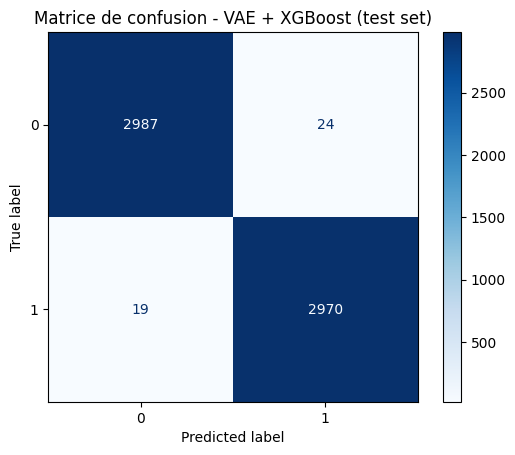

```python
from sklearn.metrics import confusion_matrix, ConfusionMatrixDisplay
import matplotlib.pyplot as plt

# Prédictions du modèle XGBoost sur les latents du test
y_pred = xgb_model_finetune.predict(latent_test)

# Calcul de la matrice de confusion
cm = confusion_matrix(y_test_vae, y_pred)

# Affichage
disp = ConfusionMatrixDisplay(confusion_matrix=cm)
disp.plot(cmap='Blues')
plt.title("Matrice de confusion - VAE + XGBoost (test set)")
plt.show()
```

The confusion matrix shows that the fine-tuned VAE + XGBoost model correctly classifies almost all test samples. There are only few misclassifications: 24 false positives and 19 false negatives out of nearly 6,000 examples images and a good balance between classes. This confirms the very high test accuracy previously observed. No obvious sign of over fitting here but we can still wonder if the validation ROC Curve can prove the contrary.

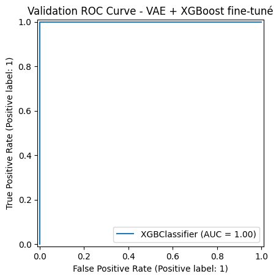

```python
from sklearn.metrics import RocCurveDisplay
import matplotlib.pyplot as plt

RocCurveDisplay.from_estimator(xgb_model_finetune, latent_sup, y_sup_train)
plt.title("Validation ROC Curve - VAE + XGBoost fine-tuné")
plt.show()
```

These metrics confirm that the model generalizes very well but it can be overfitting, due to its perfect training performance.

**7.8 Save the validation and test scores of each fine-tuned model for future comparison.**

```python
finetune_scores2 = {
    'VAE+NN_val_acc_finetune': finetune_val_acc,
    'VAE+NN_test_acc_finetune': finetune_test_acc,
    'VAE+XGB_val_acc_finetune': xgb_val_acc,
    'VAE+XGB_test_acc_finetune': xgb_test_acc
}

with open("finetune_scores2.json", "w") as f:
    json.dump(finetune_scores2, f)
```

## **8. Model Comparison**

- Collect the test scores from the seven models and organize them into a unified table.
- Interpret the results and discuss the strengths and weaknesses of each approach.

```python
import json
import pandas as pd

files = {
    "Base model": "base_scores.json",
    "CNN model": "cnn_scores.json",
    "VAE+NN (finetune)": "finetune_scores2.json",
    "ResNet50": "learning_2_scores.json",
    "VAE+NN": "transfer_scores_vae2.json"
}

data = []

for model, filename in files.items():
    with open(filename, 'r') as f:
        scores = json.load(f)

    if model == "VAE+NN (finetune)":
        # Ajout explicite des deux variantes fine-tunées
        data.append({
            "Model": "VAE+NN (finetune)",
            "Val acc": scores["VAE+NN_val_acc_finetune"],
            "Test acc": scores["VAE+NN_test_acc_finetune"]
        })
        data.append({
            "Model": "VAE+XGB (finetune)",
            "Val acc": scores["VAE+XGB_val_acc_finetune"],
            "Test acc": scores["VAE+XGB_test_acc_finetune"]
        })

    elif "val_acc" in scores and "test_acc" in scores:
        data.append({
            "Model": model,
            "Val acc": scores["val_acc"],
            "Test acc": scores["test_acc"]
        })

    elif "base_val_acc" in scores and "base_test_acc" in scores:
        data.append({
            "Model": model,
            "Val acc": scores["base_val_acc"],
            "Test acc": scores["base_test_acc"]
        })

    elif "val_accuracy_last_epoch_2" in scores and "test_accuracy_2" in scores:
        data.append({
            "Model": model,
            "Val acc": scores["val_accuracy_last_epoch_2"],
            "Test acc": scores["test_accuracy_2"]
        })

    else:
        # Pour les fichiers comme transfer_scores_vae2.json
        for key, val in scores.items():
            if "val_acc" in key:
                test_key = key.replace("val", "test")
                model_name = key.replace("_val_acc", "").replace("VAE+", "VAE+").replace("_", " ")
                data.append({
                    "Model": model_name.strip(),
                    "Val acc": val,
                    "Test acc": scores.get(test_key, None)
                })

# Création du DataFrame
df = pd.DataFrame(data)
print(df)

# Affichage stylisé
display(df.style.set_caption("Model Comparison")
              .format({"Val acc": "{:.4f}", "Test acc": "{:.4f}"})
              .background_gradient(subset=["Val acc", "Test acc"], cmap='Purples'))
```

```
                Model   Val acc  Test acc
0          Base model  0.983333  0.988667
1           CNN model  0.997556  0.996889
2   VAE+NN (finetune)  0.999306  0.993833
3  VAE+XGB (finetune)  1.000000  0.992833
4            ResNet50  0.942292  0.948833
5              VAE+NN  0.960833  0.961500
6             VAE+XGB  0.958333  0.961000
```

Model Comparison

|  | Model | Val acc | Test acc |
| --- | --- | --- | --- |
| 0 | Base model | 0.9833 | 0.9887 |
| 1 | CNN model | 0.9976 | 0.9969 |
| 2 | VAE+NN (finetune) | 0.9993 | 0.9938 |
| 3 | VAE+XGB (finetune) | 1.0000 | 0.9928 |
| 4 | ResNet50 | 0.9423 | 0.9488 |
| 5 | VAE+NN | 0.9608 | 0.9615 |
| 6 | VAE+XGB | 0.9583 | 0.9610 |

## **9. Face Detection**

Use the function detect and classify faces to detect and classify faces in the provided image student.png using your best classification model.

```python
from tensorflow.keras.models import Sequential
from tensorflow.keras.layers import Conv2D, MaxPooling2D, Flatten, Dense, Dropout
from tensorflow.keras.callbacks import EarlyStopping
from sklearn.model_selection import train_test_split
from tensorflow.keras.utils import to_categorical

# Temporary X variable
X = np.load('X_images.npy')

# Split en train, validation, test
X_train, X_temp, y_train, y_temp = train_test_split(X, Y_labels, test_size=0.3, random_state=42, stratify=Y_labels)
X_val, X_test, y_val, y_test = train_test_split(X_temp, y_temp, test_size=0.5, random_state=42, stratify=y_temp)

X_train_cnn = X_train.reshape(-1, 54, 54, 3)
X_val_cnn = X_val.reshape(-1, 54, 54, 3)
X_test_cnn = X_test.reshape(-1, 54, 54, 3)

# Build CNN Model
best_model = Sequential([
    Conv2D(32, (3, 3), activation='relu', input_shape=(54, 54, 3)),
    MaxPooling2D((2, 2)),
    Conv2D(64, (3, 3), activation='relu'),
    MaxPooling2D((2, 2)),
    Flatten(),
    Dense(128, activation='relu'),
    Dropout(0.5),
    Dense(1, activation='sigmoid')
])

best_model.compile(optimizer='adam', loss='binary_crossentropy', metrics=['accuracy'])

# Early stopping
early_stop = EarlyStopping(patience=5, restore_best_weights=True)

# Training
history_cnn = best_model.fit(
    X_train_cnn, y_train,
    epochs=20,
    batch_size=64,
    validation_data=(X_val_cnn, y_val),
    callbacks=[early_stop]
)

# Compute validation and test scores
val_loss, val_acc = best_model.evaluate(X_val_cnn, y_val, verbose=0)
test_loss, test_acc = best_model.evaluate(X_test_cnn, y_test, verbose=0)
```

```
329/329 ━━━━━━━━━━━━━━━━━━━━ 7s 15ms/step - accuracy: 0.9005 - loss: 0.2287 - val_accuracy: 0.9884 - val_loss: 0.0372
329/329 ━━━━━━━━━━━━━━━━━━━━ 7s 7ms/step - accuracy: 0.9929 - loss: 0.0255 - val_accuracy: 0.9953 - val_loss: 0.0187
329/329 ━━━━━━━━━━━━━━━━━━━━ 2s 7ms/step - accuracy: 0.9931 - loss: 0.0213 - val_accuracy: 0.9958 - val_loss: 0.0168
329/329 ━━━━━━━━━━━━━━━━━━━━ 2s 7ms/step - accuracy: 0.9967 - loss: 0.0124 - val_accuracy: 0.9911 - val_loss: 0.0315
329/329 ━━━━━━━━━━━━━━━━━━━━ 2s 7ms/step - accuracy: 0.9960 - loss: 0.0150 - val_accuracy: 0.9964 - val_loss: 0.0144
329/329 ━━━━━━━━━━━━━━━━━━━━ 3s 8ms/step - accuracy: 0.9974 - loss: 0.0093 - val_accuracy: 0.9962 - val_loss: 0.0145
329/329 ━━━━━━━━━━━━━━━━━━━━ 2s 7ms/step - accuracy: 0.9978 - loss: 0.0084 - val_accuracy: 0.9956 - val_loss: 0.0185
329/329 ━━━━━━━━━━━━━━━━━━━━ 2s 7ms/step - accuracy: 0.9983 - loss: 0.0056 - val_accuracy: 0.9967 - val_loss: 0.0125
329/329 ━━━━━━━━━━━━━━━━━━━━ 3s 7ms/step - accuracy: 0.9981 - loss: 0.0064 - val_accuracy: 0.9964 - val_loss: 0.0161
329/329 ━━━━━━━━━━━━━━━━━━━━ 2s 7ms/step - accuracy: 0.9983 - loss: 0.0058 - val_accuracy: 0.9967 - val_loss: 0.0135
329/329 ━━━━━━━━━━━━━━━━━━━━ 3s 8ms/step - accuracy: 0.9974 - loss: 0.0067 - val_accuracy: 0.9971 - val_loss: 0.0105
329/329 ━━━━━━━━━━━━━━━━━━━━ 2s 7ms/step - accuracy: 0.9993 - loss: 0.0021 - val_accuracy: 0.9973 - val_loss: 0.0109
329/329 ━━━━━━━━━━━━━━━━━━━━ 2s 7ms/step - accuracy: 0.9987 - loss: 0.0039 - val_accuracy: 0.9964 - val_loss: 0.0130
329/329 ━━━━━━━━━━━━━━━━━━━━ 3s 7ms/step - accuracy: 0.9988 - loss: 0.0044 - val_accuracy: 0.9967 - val_loss: 0.0150
329/329 ━━━━━━━━━━━━━━━━━━━━ 2s 7ms/step - accuracy: 0.9991 - loss: 0.0028 - val_accuracy: 0.9971 - val_loss: 0.0104
329/329 ━━━━━━━━━━━━━━━━━━━━ 3s 8ms/step - accuracy: 0.9974 - loss: 0.0089 - val_accuracy: 0.9971 - val_loss: 0.0164
329/329 ━━━━━━━━━━━━━━━━━━━━ 5s 7ms/step - accuracy: 0.9991 - loss: 0.0026 - val_accuracy: 0.9933 - val_loss: 0.0384
329/329 ━━━━━━━━━━━━━━━━━━━━ 2s 7ms/step - accuracy: 0.9992 - loss: 0.0028 - val_accuracy: 0.9969 - val_loss: 0.0166
329/329 ━━━━━━━━━━━━━━━━━━━━ 2s 7ms/step - accuracy: 0.9995 - loss: 0.0014 - val_accuracy: 0.9980 - val_loss: 0.0122
329/329 ━━━━━━━━━━━━━━━━━━━━ 3s 8ms/step - accuracy: 0.9997 - loss: 0.0011 - val_accuracy: 0.9969 - val_loss: 0.0126
```

In this part, we instantiate our CNN model with the exact same code as earlier.

```python
import cv2
import numpy as np
from google.colab.patches import cv2_imshow

# Load a pre-trained face detector to find potential face regions in the image
face_d = cv2.CascadeClassifier(cv2.data.haarcascades + 'haarcascade_frontalface_default.xml')

def detect_and_classify_faces(image_path, model):
    image = cv2.imread(image_path)
    gray = cv2.cvtColor(image, cv2.COLOR_BGR2GRAY)
    faces = face_d.detectMultiScale(gray, scaleFactor=1.1, minNeighbors=5, minSize=(30, 30))

    for (x, y, w, h) in faces:
        face = image[y:y+h, x:x+w]
        face_resized = cv2.resize(face, (54, 54)).astype('float32') / 255.0
        face_resized = face_resized.reshape((1, 54, 54, 3))

        prediction = model.predict(face_resized)[0][0]
        label = f"Face ({prediction:.2f})" if prediction > 0.5 else f"Not Face ({prediction:.2f})"

        cv2.rectangle(image, (x, y), (x+w, y+h), (0, 255, 0) if prediction > 0.5 else (0, 0, 255), 2)
        cv2.putText(image, label, (x, y-10), cv2.FONT_HERSHEY_SIMPLEX, 0.9,
                    (0, 255, 0) if prediction > 0.5 else (0, 0, 255), 2)

    cv2_imshow(image)
```

The image is converted to grayscale, which is required by the Haar Cascade face detector used here. The **CascadeClassifier** scans the image for facial features and returns bounding boxes around detected face regions.

Each region is then cropped, resized to 54×54 pixels (matching the model's input shape), normalized, and reshaped to fit the CNN's expected input format.

The image is displayed with rectangles around each detected face. Green rectangles and labels indicate the model predicts a face with high confidence, while red indicates the opposite.

**Test of the model**

```
1/1 ━━━━━━━━━━━━━━━━━━━━ 0s 31ms/step
1/1 ━━━━━━━━━━━━━━━━━━━━ 0s 29ms/step
1/1 ━━━━━━━━━━━━━━━━━━━━ 0s 30ms/step
1/1 ━━━━━━━━━━━━━━━━━━━━ 0s 29ms/step
1/1 ━━━━━━━━━━━━━━━━━━━━ 0s 32ms/step
```

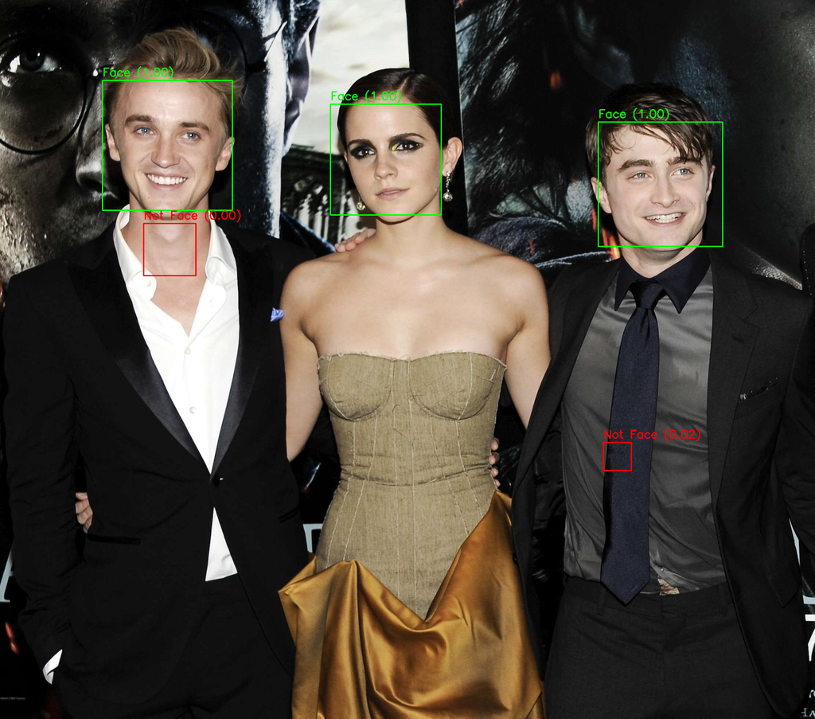

```python
detect_and_classify_faces("student.png", best_model)
```

We have 3 faces detected with **1.00 probability**, then we have rectangles "not face" with **0.00 and 0.02 probability**. Our model detected all the faces present on the image and have strong probability.

Th only score which is not perfect is the 0.02 for the "not-face" part. Again, the detection of "not-face" seems to be more difficult than the "face" because of the diversity of possibility on the "not-face".

## **10. Face Generation with GAN**

Now we want to implement a Generative Adversarial Network (GAN) to generate realistic fake face images based on the images with label "face" in our dataset. This part is composed of these steps :

- Write code to display 25 face images from the trainloader
- Implement a Discriminator class that processes the face images. The input size for the nn.Linear layer should be the size of the flattened output.
- Implement a Generator class that generates fake face images. Ensure that the final output size of the generator is (3, 54, 54). You can achieve this by carefully choosing the output channels, kernel sizes, strides, and number of layers in the generator.
- Write code to initialize the weights of the generator and discriminator using a normal distribution.
- Define the loss function and optimizers for both the generator and discriminator.
- Implement the training loop for the GAN. After each epoch, display 9 images generated by the generator.

```python
import numpy as np
import torch
from torch.utils.data import Dataset , DataLoader
from torchvision import transforms
import torch.nn as nn
import torch.optim as optim
import matplotlib.pyplot as plt
from tqdm import tqdm
from torchsummary import summary

X_images = np.load('X_images.npy')
Y_labels = np.load('Y_labels.npy')

print("Dataset size : ", len(X_images))
print("Image size : ", X_images[0].shape)

# Preprocessing
Y_labels = Y_labels.reshape(-1)
faces_images = X_images[Y_labels == 1] # we only keep face images which are already normalized
faces_labels = Y_labels[Y_labels  == 1]

# Initialize Parameters
device = torch.device("cuda" if torch.cuda.is_available() else "cpu")
z_dim = 100 # Size of the input noise vector to the generator
epochs = 20
batch_size = 128
lr = 2e-4 # learning rate

transform = transforms.Compose([
    transforms.ToPILImage(),
    transforms.Resize((64, 64)),  # Resize in 64x64 for compatibility with GAN because 53 and 54 are not powers of two, so upsampling and downsampling is not clean
    transforms.ToTensor(),
    transforms.Normalize((0.5,), (0.5,))  # [-1, 1]
])

class CustomDataset(Dataset):
    def __init__(self, images, labels, transform=None):
        self.images = images
        self.labels = labels
        self.transform = transform

    def __len__(self):
        return len(self.images)

    def __getitem__(self, idx):
        image = self.images[idx]
        label = self.labels[idx]
        if self.transform:
            image = self.transform(image)
        return image, label


trainset = CustomDataset(faces_images, faces_labels, transform=transform)
# We load 128 batches of real face images for the training
trainloader = DataLoader(trainset, batch_size=batch_size, shuffle=True)
```

```
Dataset size :  30000
Image size :  (54, 54, 3)
```

**10.1 - Display 25 face images from the batches of the trainloader**

[figure not shown]

```python
import matplotlib.pyplot as plt

# Get one batch from the trainloader
dataiter = iter(trainloader)
images, labels = next(dataiter)

# Denormalize the images for visualization
images = images * 0.5 + 0.5  # Undo normalization: (x * std) + mean

# Display 25 images
fig, axes = plt.subplots(5, 5, figsize=(8, 8))
axes = axes.flatten()

for i in range(25):
    img = images[i].permute(1, 2, 0).numpy()
    axes[i].imshow(img.squeeze())
    axes[i].axis('off')

plt.tight_layout()
plt.show()
```

**10.2 - Discriminator class implementation : to distinguish fake and real images**

We create the Discriminator that will learn to distinguish between real and fake images, it is compsed of :

- 4 Convolutional layers for features extraction for RGB images
- 3 Batch Normalization layers to stabilize the learning after the 3 last convolutional layers
- 4 LeakyReLU layers for non-linear activation
- 1 Flatten layer to reduce 4D output into 2D vector
- 1 Fully connected layer to distinguish real and fake face images
- 1 last Sigmoid Dense layer to tranform the prediction in a probability between 0 and 1

```python
class Discriminator(nn.Module):
    def __init__(self):
        super().__init__()
        self.model = nn.Sequential(
            nn.Conv2d(3, 64, 4, 2, 1),  # 32x32
            nn.LeakyReLU(0.2, inplace=True),

            nn.Conv2d(64, 128, 4, 2, 1),  # 16x16
            nn.BatchNorm2d(128),
            nn.LeakyReLU(0.2, inplace=True),

            nn.Conv2d(128, 256, 4, 2, 1),  # 8x8
            nn.BatchNorm2d(256),
            nn.LeakyReLU(0.2, inplace=True),

            nn.Conv2d(256, 512, 4, 2, 1),  # 4x4
            nn.BatchNorm2d(512),
            nn.LeakyReLU(0.2, inplace=True),

            nn.Flatten(),
            nn.Linear(512*4*4, 1),
            nn.Sigmoid()
        )

    def forward(self, x):
        return self.model(x)
```

```python
D = Discriminator().to(device)
```

**10.3 - Generator class implementation : to generate fake images**

We create the Generator that will learn to produce fake face images resembling the training data. It is composed of :

- 5 ConvTranspose2d layers to upsample the latent vector into an image of size 64x64 with 3 color channels
- 4 Batch Normalization layers to stabilize the learning
- 4 ReLU activations for non-linear transformation, except the final layer
- 1 Tanh activation to produce output pixel values between -1 and 1 to match the normalization of input images

```python
class Generator(nn.Module):
    def __init__(self):
        super().__init__()
        self.model = nn.Sequential(
            nn.ConvTranspose2d(z_dim, 512, 4, 1, 0),  # 4x4
            nn.BatchNorm2d(512),
            nn.ReLU(True),

            nn.ConvTranspose2d(512, 256, 4, 2, 1),  # 8x8
            nn.BatchNorm2d(256),
            nn.ReLU(True),

            nn.ConvTranspose2d(256, 128, 4, 2, 1),  # 16x16
            nn.BatchNorm2d(128),
            nn.ReLU(True),

            nn.ConvTranspose2d(128, 64, 4, 2, 1),   # 32x32
            nn.BatchNorm2d(64),
            nn.ReLU(True),

            nn.ConvTranspose2d(64, 3, 4, 2, 1),     # 64x64
            nn.Tanh()
        )

    def forward(self, x):
        return self.model(x)
```

```python
G = Generator().to(device)
```

**10.4 - Initialize the weights of the generator and discriminator using a normal distribution**

This step will initialize the weights, with a normal distribution centered at 0, of the convolutional, transposed convolutional, and linear layers in the Generator and the Discriminator. It will help to stabilize the learning and will ensure the significance of the the features.

```python
def weights_init(m):
    if isinstance(m, (nn.Conv2d, nn.ConvTranspose2d, nn.Linear)):
        nn.init.normal_(m.weight.data, 0.0, 0.02)
        if m.bias is not None:
            nn.init.constant_(m.bias.data, 0)
```

```python
# Apply the weights to the Generator and the Discriminator
D.apply(weights_init)
G.apply(weights_init)
```

```
Generator(
  (model): Sequential(
    (0): ConvTranspose2d(100, 512, kernel_size=(4, 4), stride=(1, 1))
    (1): BatchNorm2d(512, eps=1e-05, momentum=0.1, affine=True, track_running_stats=True)
    (2): ReLU(inplace=True)
    (3): ConvTranspose2d(512, 256, kernel_size=(4, 4), stride=(2, 2), padding=(1, 1))
    (4): BatchNorm2d(256, eps=1e-05, momentum=0.1, affine=True, track_running_stats=True)
    (5): ReLU(inplace=True)
    (6): ConvTranspose2d(256, 128, kernel_size=(4, 4), stride=(2, 2), padding=(1, 1))
    (7): BatchNorm2d(128, eps=1e-05, momentum=0.1, affine=True, track_running_stats=True)
    (8): ReLU(inplace=True)
    (9): ConvTranspose2d(128, 64, kernel_size=(4, 4), stride=(2, 2), padding=(1, 1))
    (10): BatchNorm2d(64, eps=1e-05, momentum=0.1, affine=True, track_running_stats=True)
    (11): ReLU(inplace=True)
    (12): ConvTranspose2d(64, 3, kernel_size=(4, 4), stride=(2, 2), padding=(1, 1))
    (13): Tanh()
  )
)
```

Impact of the weights :

- For the Discriminator, it keeps it from being too strong at the beginning.
- For the Generator, good weight initialization helps it start making good images faster.

**10.5 - Definition of the loss function and optimizers for both the generator and discriminator.**

```python
criterion = nn.BCELoss()
```

We use the BCELoss (Binary Cross Entropy) which is good for GAN because it helps the Discriminator learn to tell the difference between real and fake images by comparing predictions to target labels (1 for real, 0 for fake).

```python
optimizer_G = optim.Adam(G.parameters(), lr=lr, betas=(0.5, 0.999))
optimizer_D = optim.Adam(D.parameters(), lr=lr, betas=(0.5, 0.999))
```

Then for training the Generator and the Discriminator, we used the Adam optimizer with the usual settings: betas=(0.5, 0.999). This helps make the training more stable.

**10.6 - Implementation of the training loop for the GAN. After each epoch, we display 9 images generated by the generator.**

The training loop runs for 20 epochs. In each epoch, we first train the Discriminator to distinguish real and fake face images. It sees real faces with label 0.9 and fake images from the Generator with label 0.0. The total loss for the Discriminator comes from both.

Then we train the Generator. It tries to fool the Discriminator by generating fake images that look real (label = 0.9). Its goal is to make the Discriminator believe that the fake images are real. When the Discriminator is fooled, the Generator assigns a high probability to fake images being real (label = 0.9), which matches the target label. This reduces the Generator’s loss, because the predicted output is close to what it wants.